# Estudio de Asistentes al CTBA

Federico M. Bonazzi -Data Cultura BA-

2019-07-11

# ASISTENTES AL TEATRO EN CABA

## *Un acercamiento a partir de los asistentes al CTBA*

## PROPÓSITO

El propósito de este informe es poder caracterizar a los asistentes al Complejo Teatral Buenos Aires (CTBA), a partir de la base de usuario de quienes compraron entradas via online en 2018. Para ello, se describirá la base a partir de sus distintas variables. Además, a través de herramientas geoespaciales, se cruzará la información de los asistentes con información censal para establecer su perfil sociodemográfico (observando qué caracteristicas son estadísticamente significativas para establecer dicho perfil).

## DATASETS

El principal Dataset a utilizar es el de usuario de CTBA para el año 2018. Este dataset presenta todas las transacciones online para la adiquisicion de entradas a funciones de teatro circuito oficial. Las variables que presenta son: *Nombre, apellido, mail del usuario.* Fecha de nacimiento de los usuarios *Domicilio* Ciudad *Provincia* País *CP* Género: del comprador *Evento: qué obra de teatro, recital, etc* Día *Lugar: teatro en el que se realizó la función

Otros dataset a utilizar son: 1- ESPACIOS CULTURALES DE LA CIUDAD DE BUENOS AIRES, de Data Cultura BA. Para obtener información de los espacios culturales de la CABA. 2-Información censal por radio de la Ciudad de Buenos Aires, a partir del Censo 2010, georreferenciados. 3-Barrios de la CABA, de Data BA, georreferenciados.

## DESARROLLO

### Puesta a punto y exploración de la base

Se abren las librerias que se utilizarán

```r
library (tidyverse)
library (ggplot2)
library(sf)
library(httr)
library(jsonlite)
library(readr)
library(lubridate)
library(tufte)
library(eeptools)
library ("sp")
library(rgeos)
library(lwgeom)
```

Se carga la base de usuarios de CTBA y se osberva cómo se compone el dataset

```r
ctba18 <- read_csv("C:/Users/Claudia/Documents/R/GCBA Datos/Taller CABA/ctba18.csv")

str(ctba18)
```

```
## Classes 'spec_tbl_df', 'tbl_df', 'tbl' and 'data.frame': 25789 obs. of  19 variables:
##  $ Nombre               : chr  "venceslao ariel" "Patricio" "Patricio German" "paula" ...
##  $ Apellido             : chr  "gerlich" "Uranga" "Barletta" "briuolo" ...
##  $ Documento            : chr  "24501520" "28910621" "35725907" "10203040" ...
##  $ Fecha de nac.        : Date, format: "1975-03-02" "1981-06-25" ...
##  $ Mail                 : chr  "agerlich75@gmail.com" "pato_u@hotmail.com" "pbarletta@gmail.com" "pbriuolo@gmail.com" ...
##  $ Domicilio            : chr  "combate de los pozos 1138 3 c" "Av Díaz Vélez 3841" "Moctezuma 1036" "Potosí 4052" ...
##  $ Ciudad               : chr  "caba" "CABA" "C.A.B.A" "caba" ...
##  $ Provincia            : chr  "Ciudad Autonoma de Buenos Aires" "Ciudad Autonoma de Buenos Aires" "Ciudad Autonoma de Buenos Aires" "Ciudad Autonoma de Buenos Aires" ...
##  $ CP                   : chr  "1222" "1200" "1407" "1199" ...
##  $ Pais                 : chr  "Argentina" "Argentina" "Argentina" "Argentina" ...
##  $ Genero               : chr  "H" "H" "H" "M" ...
##  $ Evento               : chr  "La vuelta al mundo en 80 mundos" "Madre coraje" "La vuelta al mundo en 80 mundos" "Blum" ...
##  $ Dia                  : POSIXct, format: "2018-07-21 15:00:00" "2018-12-01 21:00:00" ...
##  $ Lugar                : chr  "CTBA - Teatro Regio" "CTBA - Teatro Regio" "CTBA - Teatro Regio" "CTBA - Teatro Regio" ...
##  $ columna_14           : logi  NA NA NA NA NA NA ...
##  $ direccion_normalizada: chr  "COMBATE DE LOS POZOS 1138, CABA" "DIAZ VELEZ AV. 3841, CABA" "MOCTEZUMA 1036, CABA" "POTOSI 4052, CABA" ...
##  $ geometry             : chr  "POINT (-58.3930035897 -34.6220360987)" "POINT (-58.4205179695 -34.6084677)" "POINT (-58.4949711811 -34.627832926)" "POINT (-58.4237642146 -34.6073197621)" ...
##  $ barrio               : chr  "San Cristóbal" "Almagro" "Vélez Sarsfield" "Almagro" ...
##  $ comuna               : chr  "Comuna 3" "Comuna 5" "Comuna 10" "Comuna 5" ...
##  - attr(*, "spec")=
##   .. cols(
##   ..   Nombre = col_character(),
##   ..   Apellido = col_character(),
##   ..   Documento = col_character(),
##   ..   `Fecha de nac.` = col_date(format = ""),
##   ..   Mail = col_character(),
##   ..   Domicilio = col_character(),
##   ..   Ciudad = col_character(),
##   ..   Provincia = col_character(),
##   ..   CP = col_character(),
##   ..   Pais = col_character(),
##   ..   Genero = col_character(),
##   ..   Evento = col_character(),
##   ..   Dia = col_datetime(format = ""),
##   ..   Lugar = col_character(),
##   ..   columna_14 = col_logical(),
##   ..   direccion_normalizada = col_character(),
##   ..   geometry = col_character(),
##   ..   barrio = col_character(),
##   ..   comuna = col_character()
##   .. )
```

El dataset tiene 25789 observaciones (aquí refieren a transacciones realizadas).

Se observa que la columna que debe proveer la ubicación geográfica, está como clase character, por lo que tengo que tranformarla. Se define también el sistema de coordenadas (4326).

```r
ctba18$geometry <- st_as_sfc(ctba18$geometry, crs = 4326)

class(ctba18$geometry)
```

```
## [1] "sfc_POINT" "sfc"
```

A continuación exploro los valores que presenta el dataset:

```r
summary(ctba18)
```

```
##     Nombre            Apellido          Documento
##  Length:25789       Length:25789       Length:25789
##  Class :character   Class :character   Class :character
##  Mode  :character   Mode  :character   Mode  :character
##
##
##
##
##  Fecha de nac.            Mail            Domicilio
##  Min.   :1759-06-12   Length:25789       Length:25789
##  1st Qu.:1960-10-26   Class :character   Class :character
##  Median :1974-04-16   Mode  :character   Mode  :character
##  Mean   :1996-09-02
##  3rd Qu.:1986-01-09
##  Max.   :4089-10-15
##  NA's   :130
##     Ciudad           Provincia              CP
##  Length:25789       Length:25789       Length:25789
##  Class :character   Class :character   Class :character
##  Mode  :character   Mode  :character   Mode  :character
##
##
##
##
##      Pais              Genero             Evento
##  Length:25789       Length:25789       Length:25789
##  Class :character   Class :character   Class :character
##  Mode  :character   Mode  :character   Mode  :character
##
##
##
##
##       Dia                         Lugar           columna_14
##  Min.   :2018-03-01 21:00:00   Length:25789       Mode:logical
##  1st Qu.:2018-06-01 20:30:00   Class :character   NA's:25789
##  Median :2018-08-03 20:00:00   Mode  :character
##  Mean   :2018-08-02 18:52:30
##  3rd Qu.:2018-09-29 17:00:00
##  Max.   :2018-12-16 20:30:00
##
##  direccion_normalizada          geometry        barrio
##  Length:25789          POINT        :25789   Length:25789
##  Class :character      epsg:4326    :    0   Class :character
##  Mode  :character      +proj=long...:    0   Mode  :character
##
##
##
##
##     comuna
##  Length:25789
##  Class :character
##  Mode  :character
##
##
##
##
```

Se analizan algunas columnas para ver si son utiles para el análisis o se pueden desechar

```r
head (ctba18$Ciudad,20)
```

```
##  [1] "caba"                            "CABA"
##  [3] "C.A.B.A"                         "caba"
##  [5] "lanus"                           "CAPITAL FEDERAL"
##  [7] "CABA"                            "San Martín"
##  [9] "CABA"                            "CABA"
## [11] "Caba"                            "Caballito"
## [13] "capital federal"                 "belgrano"
## [15] "Capital Federal"                 "palermo"
## [17] "buenos aires"                    "caba"
## [19] "Caba"                            "Ciudad Autónoma de Buenos Aires"
```

```r
head (ctba18$Provincia, 20)
```

```
##  [1] "Ciudad Autonoma de Buenos Aires" "Ciudad Autonoma de Buenos Aires"
##  [3] "Ciudad Autonoma de Buenos Aires" "Ciudad Autonoma de Buenos Aires"
##  [5] "Buenos Aires"                    "CAPITAL FEDERAL"
##  [7] "Ciudad Autonoma de Buenos Aires" "Buenos Aires"
##  [9] "Ciudad de Buenos Aires"          "Buenos Aires"
## [11] "Ciudad Autonoma de Buenos Aires" "Capital Federal"
## [13] "Ciudad Autonoma de Buenos Aires" "Ciudad Autonoma de Buenos Aires"
## [15] "Ciudad Autonoma de Buenos Aires" "Ciudad Autonoma de Buenos Aires"
## [17] "C.A.B.A."                        "Ciudad Autonoma de Buenos Aires"
## [19] "Buenos Aires"                    "Ciudad Autonoma de Buenos Aires"
```

```r
table (ctba18$comuna)
```

```
##
##  Comuna 1 Comuna 10 Comuna 11 Comuna 12 Comuna 13 Comuna 14 Comuna 15
##      2852       722      1041      1605      3135      3779      2680
##  Comuna 2  Comuna 3  Comuna 4  Comuna 5  Comuna 6  Comuna 7  Comuna 8
##      1965      1593       907      1865      1984      1040       146
##  Comuna 9
##       474
```

```r
table (ctba18$Lugar)
```

```
##
##                       CTBA - CCK - Sala Argentina
##                                                 5
##                       CTBA - CCK - Sala Sinfonica
##                                                 5
##                    CTBA - Parroquia San Ildefonso
##                                                 5
##                        CTBA - Teatro de la Ribera
##                                               950
##                               CTBA - Teatro Regio
##                                              8132
##          CTBA - Teatro San Martin - CEDOC 4° piso
##                                                57
##       CTBA - Teatro San Martin - Sala Casacuberta
##                                              6612
##   CTBA - Teatro San Martin - Sala Casacuberta S/N
##                                                88
## CTBA - Teatro San Martin - Sala Cunill Cabanellas
##                                              2064
##   CTBA - Teatro San Martin - Sala Martin Coronado
##                                              4570
##        CTBA - Teatro San Martin  Visitas guiadas
##                                                 2
##                           CTBA - Teatro Sarmiento
##                                              3299
```

```r
head (ctba18$barrio, 20)
```

```
##  [1] "San Cristóbal"    "Almagro"          "Vélez Sarsfield"
##  [4] "Almagro"          "Parque Chacabuco" "Recoleta"
##  [7] "Chacarita"        "Almagro"          "Palermo"
## [10] "Palermo"          "Palermo"          "Caballito"
## [13] "Mataderos"        "Belgrano"         "Villa Ortúzar"
## [16] "Colegiales"       "Almagro"          "Belgrano"
## [19] "Almagro"          "Parque Patricios"
```

```r
head (ctba18$CP, 20)
```

```
##  [1] "1222"  "1200"  "1407"  "1199"  "1824"  "1425"  "1427"  "1650"
##  [9] "1425"  "1426"  "1425"  "1424"  "1440"  "1428"  "1430"  "1426"
## [17] "1177"  "1428"  "1704"  "C1437"
```

```r
table (ctba18$Genero)
```

```
##
##     H     M
##  9656 15888
```

Se observa que CP, Ciudad y Provincia están muy sucias, además, esa información ya está provista por la geolocalización, la variable barrio y comuna. Lo mismo sucede con la variable Domicilio. Para identificar a cada usuario, se utilizará la variable mail.

Limpiar el data set, generando uno nuevo con menos variables

```r
ctba18v0 <-  ctba18 %>%
  select ( -Domicilio , -Ciudad, -Provincia, -CP, -Nombre, -Apellido, -Documento, -Pais, -columna_14)
```

Comola información venía a nivel sala de teatro (varibale Lugar), se crea una nueva definiendo los teatros:

```r
ctba18v0 <- mutate (ctba18v0, teatro =  Lugar)

ctba18v0$teatro <- ctba18v0$teatro %>%
  str_replace ("CTBA - CCK - Sala Argentina", "CCK") %>%
  str_replace ("CTBA - CCK - Sala Sinfonica", "CCK") %>%
  str_replace ("CTBA - Teatro Sarmiento", "Teatro Sarmiento") %>%
  str_replace ("CTBA - Parroquia San Ildefonso", "Pquia San Ildefonso") %>%
  str_replace ("CTBA - Teatro de la Ribera", "Teatro de la Ribera") %>%
  str_replace ( "CTBA - Teatro Regio", "Teatro Regio") %>%
  str_replace ("CTBA - Teatro San Martin - CEDOC 4° piso", "Teatro San Martin") %>%
  str_replace ( "CTBA - Teatro San Martin - Sala Casacuberta", "Teatro San Martin") %>%
  str_replace ( "CTBA - Teatro San Martin - Sala Casacuberta S/N", "Teatro San Martin") %>%
  str_replace ("CTBA - Teatro San Martin - Sala Cunill Cabanellas", "Teatro San Martin") %>%
  str_replace ("CTBA - Teatro San Martin - Sala Martin Coronado", "Teatro San Martin") %>%
  str_replace ("CTBA - Teatro San Martin - Visitas guiadas", "Teatro San Martin") %>%
  str_replace ("Teatro San Martin S/N", "Teatro San Martin") %>%
  str_replace ( " CTBA - Teatro Sarmiento", "Teatro Sarmiento")

table(ctba18v0$teatro)
```

```
##
##                                        CCK
##                                         10
## CTBA - Teatro San Martin  Visitas guiadas
##                                          2
##                        Pquia San Ildefonso
##                                          5
##                        Teatro de la Ribera
##                                        950
##                               Teatro Regio
##                                       8132
##                          Teatro San Martin
##                                      13391
##                           Teatro Sarmiento
##                                       3299
```

Comienzo a analizar los resultados:

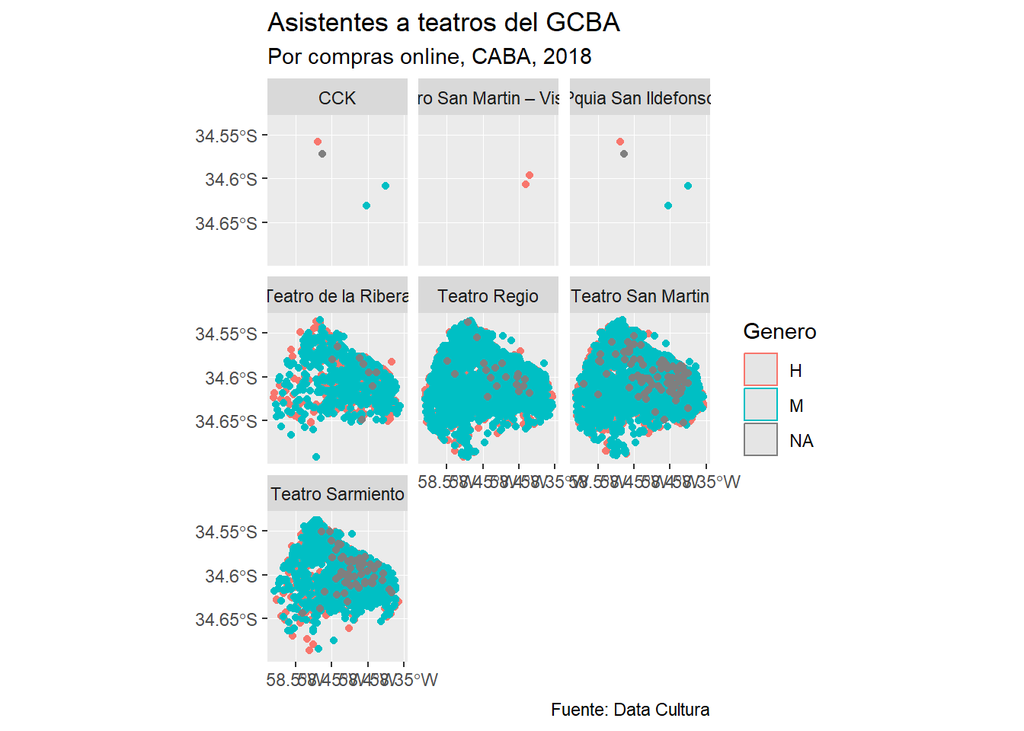

```r
ggplot() +
  geom_sf(data = ctba18v0, aes (colour = Genero)) +
  coord_sf(crs = st_crs(4326)) +
  labs(title = "Asistentes a teatros del GCBA",
         subtitle = "Por compras online, CABA, 2018",
         caption = "Fuente: Data Cultura",
         fill = "Genero") +
  facet_wrap(~teatro)
```

Se observa que el CCK y la parroquia tienen muy pocos casos y desde los mismo puntos.

```r
filter(ctba18v0, teatro == 'CCK' | teatro == 'Pquia San Ildefonso')
```

```
## # A tibble: 15 x 11
##    `Fecha de nac.` Mail  Genero Evento Dia                 Lugar
##    <date>          <chr> <chr>  <chr>  <dttm>              <chr>
##  1 NA              pedr~ <NA>   XXII ~ 2018-12-12 21:00:00 CTBA~
##  2 NA              pedr~ <NA>   XXII ~ 2018-12-12 21:00:00 CTBA~
##  3 NA              pedr~ <NA>   XXII ~ 2018-12-07 20:00:00 CTBA~
##  4 NA              pedr~ <NA>   XXII ~ 2018-12-14 20:30:00 CTBA~
##  5 1982-07-06      gonr~ H      XXII ~ 2018-12-12 21:00:00 CTBA~
##  6 1978-03-02      lore~ M      XXII ~ 2018-12-07 20:00:00 CTBA~
##  7 1982-07-06      gonr~ H      XXII ~ 2018-12-14 20:30:00 CTBA~
##  8 1978-03-02      lore~ M      XXII ~ 2018-12-14 20:30:00 CTBA~
##  9 1957-12-31      patr~ M      XXII ~ 2018-12-14 20:30:00 CTBA~
## 10 1982-07-06      gonr~ H      XXII ~ 2018-12-07 20:00:00 CTBA~
## 11 NA              pedr~ <NA>   XXII ~ 2018-12-07 20:00:00 CTBA~
## 12 1957-12-31      patr~ M      XXII ~ 2018-12-12 21:00:00 CTBA~
## 13 1978-03-02      lore~ M      XXII ~ 2018-12-12 21:00:00 CTBA~
## 14 1957-12-31      patr~ M      XXII ~ 2018-12-07 20:00:00 CTBA~
## 15 NA              pedr~ <NA>   XXII ~ 2018-12-14 20:30:00 CTBA~
## # ... with 5 more variables: direccion_normalizada <chr>, geometry <POINT
## #   [°]>, barrio <chr>, comuna <chr>, teatro <chr>
```

Todo muy sospechoso, se eliminan estos casos.

```r
ctba18v0 <- filter (ctba18v0, teatro != 'CCK' & teatro != 'Pquia San Ildefonso')

table(ctba18v0$teatro)
```

```
##
## CTBA - Teatro San Martin  Visitas guiadas
##                                          2
##                        Teatro de la Ribera
##                                        950
##                               Teatro Regio
##                                       8132
##                          Teatro San Martin
##                                      13391
##                           Teatro Sarmiento
##                                       3299
```

También se observó que hay NA en género, también se quitan.

```r
ctba18v0 <- ctba18v0 %>%
  filter(Genero != 'NA',
         comuna != 'NA')
```

Además, se agrega un layer de barrois para para ver mejor:

```r
barrios <- st_read('https://data.buenosaires.gob.ar/dataset/19/resource/1c3d185b-fdc9-474b-b41b-9bd960a3806e/download/barrios.geojson')
summary(barrios)
```

```
##        BARRIO       COMUNA               PERIMETRO                 AREA
##  AGRONOMIA: 1   1      : 6   10021.45966480549: 1   1232275.092474457: 1
##  ALMAGRO  : 1   10     : 6   10165.62712936149: 1   1279951.372561846: 1
##  BALVANERA: 1   15     : 6   10597.25280900626: 1   1334146.08283464 : 1
##  BARRACAS : 1   11     : 4   10674.41646756023: 1   1385411.513739759: 1
##  BELGRANO : 1   12     : 4   10990.96447148555: 1   1406833.595801687: 1
##  BOCA     : 1   4      : 4   11124.63579209356: 1   15772496.3315    : 1
##  (Other)  :42   (Other):18   (Other)          :42   (Other)          :42
##           geometry
##  POLYGON      :48
##  epsg:4326    : 0
##  +proj=long...: 0
##
##
##
##
```

y gafico:

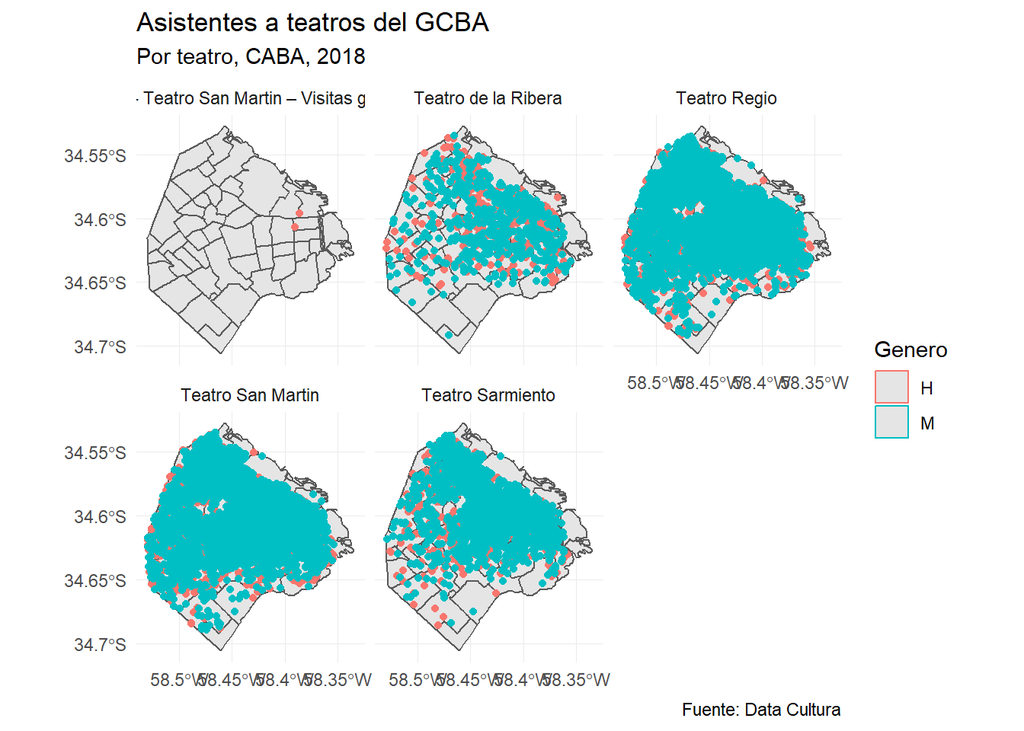

```r
ggplot() +
  geom_sf(data=barrios) +
  geom_sf(data = ctba18v0, aes (colour = Genero)) +
  coord_sf(crs = st_crs(4326)) +
  labs(title = "Asistentes a teatros del GCBA",
         subtitle = "Por teatro, CABA, 2018",
         caption = "Fuente: Data Cultura",
         fill = "Genero") +
  facet_wrap(~teatro) +
  theme_minimal()
```

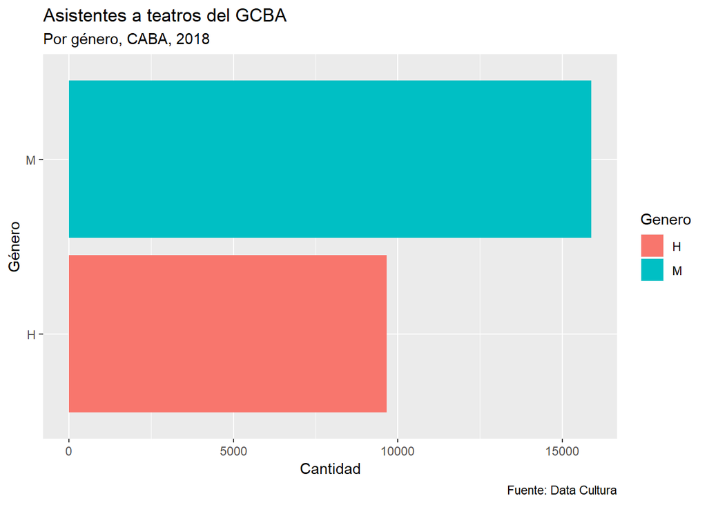

```r
ggplot(ctba18v0) +
    geom_bar (aes(x = Genero, fill = Genero)) +
    labs(title = "Asistentes a teatros del GCBA",
         subtitle = "Por género, CABA, 2018",
         caption = "Fuente: Data Cultura",
         x = "Género",
         y = "Cantidad") +
    coord_flip()
```

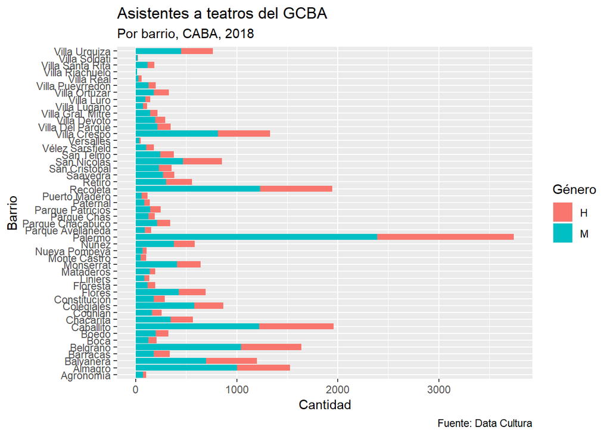

```r
ggplot(ctba18v0) +
    geom_bar (aes(x = barrio, fill = Genero)) +
  labs(title = "Asistentes a teatros del GCBA",
         subtitle = "Por barrio, CABA, 2018",
         caption = "Fuente: Data Cultura",
         x = "Barrio",
         y = "Cantidad",
       fill ="Género") +
    coord_flip()
```

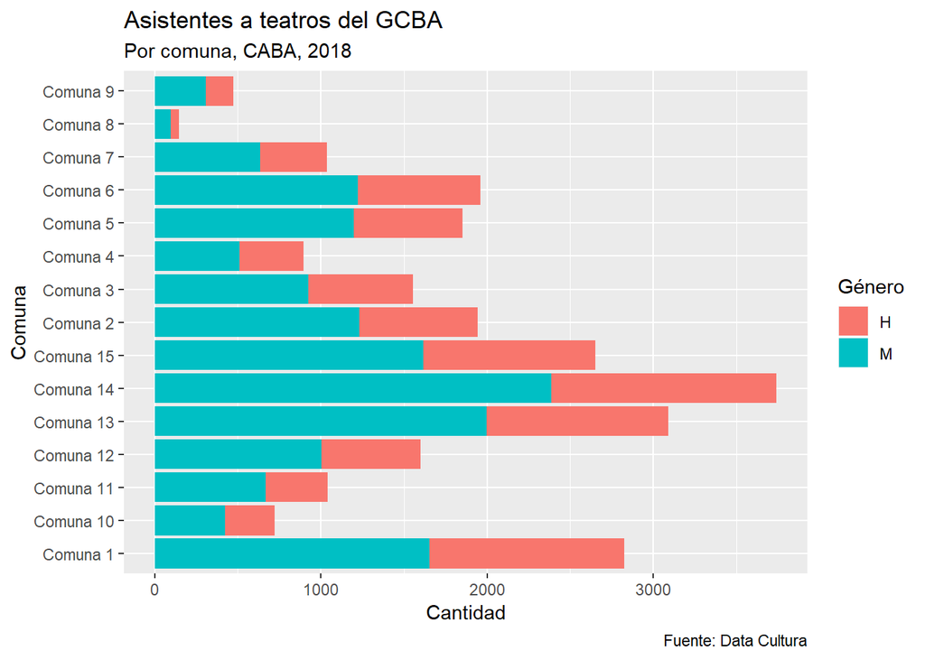

```r
ggplot(ctba18v0) +
    geom_bar (aes(x = comuna,  fill = Genero)) +
  labs(title = "Asistentes a teatros del GCBA",
         subtitle = "Por comuna, CABA, 2018",
         caption = "Fuente: Data Cultura",
         x = "Comuna",
         y = "Cantidad",
       fill ="Género") +
  coord_flip()
```

Los asistentes radican mayoritariamente en la comuna 14, 13, 1 y 15. La comuna 8 presenta muy pocos asistentes.

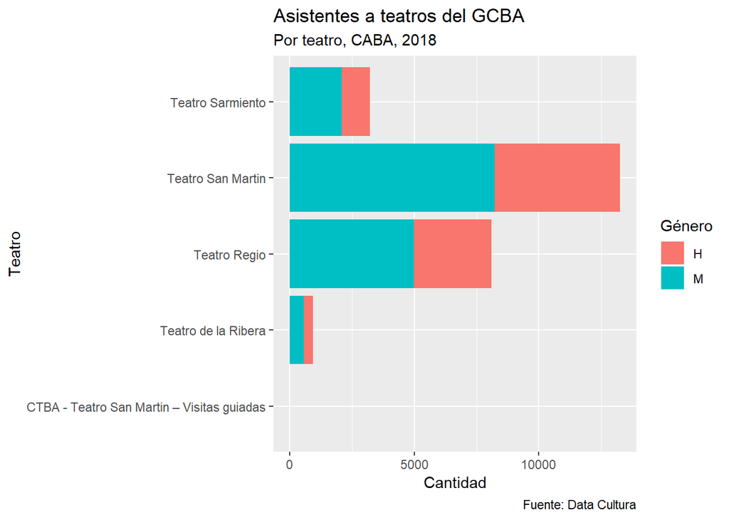

```r
ggplot(ctba18v0) +
    geom_bar(aes(x = teatro, fill = Genero)) +
  labs(title = "Asistentes a teatros del GCBA",
         subtitle = "Por teatro, CABA, 2018",
         caption = "Fuente: Data Cultura",
         x = "Teatro",
         y = "Cantidad",
       fill ="Género") +
    coord_flip()
```

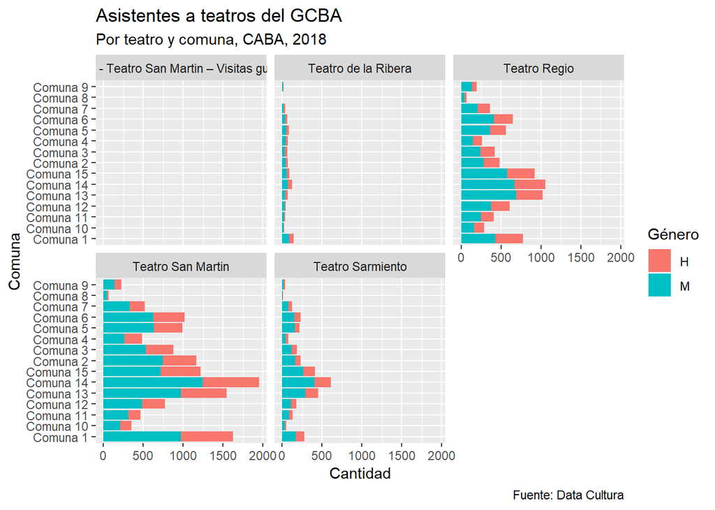

```r
ggplot(ctba18v0) +
    geom_bar(aes(x = comuna, fill = Genero)) +
    facet_wrap(~teatro) +
  labs(title = "Asistentes a teatros del GCBA",
         subtitle = "Por teatro y comuna, CABA, 2018",
         caption = "Fuente: Data Cultura",
         x = "Comuna",
         y = "Cantidad",
         fill = "Género") +
    coord_flip()
```

Se observa que el Teatro Sarmiento, que se encuentra en la Comuna 14, recibe muchos visistantes de esa misma comuna. Algo similar sucede con el teatro de la Ribera que prenta mayoria de asistentes de la comuna 1.

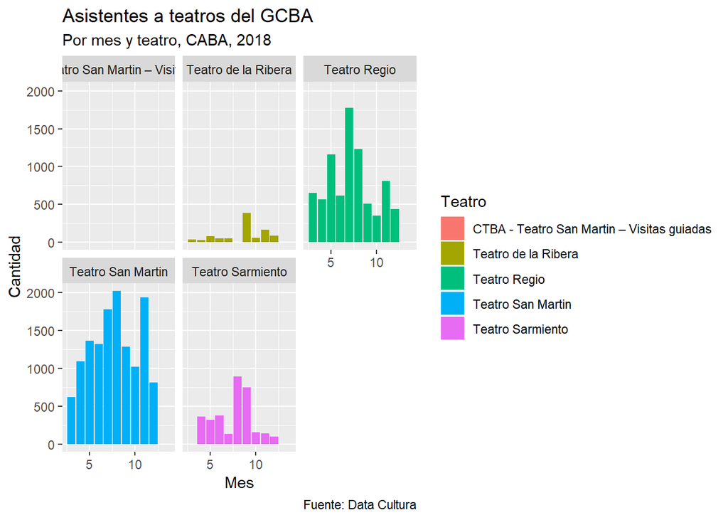

```r
ggplot(ctba18v0) +
    geom_bar(aes(x = month (Dia), fill = teatro)) +
    facet_wrap(~teatro) +
    labs(title = "Asistentes a teatros del GCBA",
         subtitle = "Por mes y teatro, CABA, 2018",
         caption = "Fuente: Data Cultura",
         x = "Mes",
         y = "Cantidad",
         fill = "Teatro")
```

Se observa en qué momento del año está concentrada la actividad en cada teatro.Así se ve que el Sarmiento tuvo picos de actividad en agosto y septiembre, que el San Martín en vacaciones de invierno (julio y agosto) y en noviembre. El teatro de la Ribera en Septiembre y el Regio en julio.

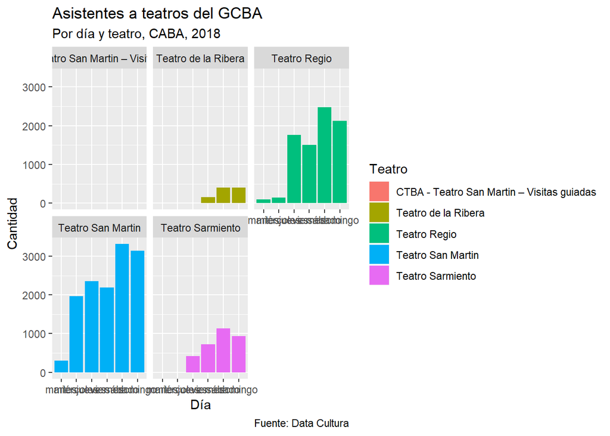

```r
ggplot(ctba18v0) +
    geom_bar(aes(x = wday (Dia, label=TRUE, abbr=FALSE, week_start = 2), fill = teatro)) +
    facet_wrap(~teatro) +
    labs(title = "Asistentes a teatros del GCBA",
         subtitle = "Por día y teatro, CABA, 2018",
         caption = "Fuente: Data Cultura",
         x = "Día",
         y = "Cantidad",
         fill = "Teatro")
```

Por otro lado, quiero calcular la edad de los asistentes, pero el dataset sólo tiene la fecha de nacimiento. Para calcularla, tengo que tener las dos variables como Date

```r
class(ctba18v0$`Fecha de nac.`)
```

```
## [1] "Date"
```

```r
class (ctba18v0$Dia)
```

```
## [1] "POSIXct" "POSIXt"
```

La variable Dia no es del tipo Date, tengo que transformarla

```r
ctba18v0 <- mutate(ctba18v0, fecha = as.Date(ctba18v0$Dia))

class(ctba18v0$fecha)
```

```
## [1] "Date"
```

Lo segundo para poder calcular es que las fechas de inicio (de nacimiento) tiene que ser menor a la de fin (momento de la transacción). Por lo que creo un nuevo dataset con la variable edad

```r
ctbaz<- subset(ctba18v0, ctba18v0$fecha > ctba18v0$`Fecha de nac.`)

ctbaz$edad <-  age_calc(ctbaz$`Fecha de nac.`, ctbaz$fecha, units = 'years', precise = TRUE)

ctbaz$edad <- round(ctbaz$edad, digits = 0)

class(ctbaz$edad)
```

```
## [1] "numeric"
```

```r
summary(ctbaz)
```

```
##  Fecha de nac.            Mail              Genero
##  Min.   :1759-06-12   Length:24358       Length:24358
##  1st Qu.:1960-01-30   Class :character   Class :character
##  Median :1972-09-18   Mode  :character   Mode  :character
##  Mean   :1972-06-12
##  3rd Qu.:1984-06-07
##  Max.   :2018-11-18
##     Evento               Dia                         Lugar
##  Length:24358       Min.   :2018-03-01 21:00:00   Length:24358
##  Class :character   1st Qu.:2018-06-01 20:37:30   Class :character
##  Mode  :character   Median :2018-08-03 20:30:00   Mode  :character
##                     Mean   :2018-08-03 02:47:47
##                     3rd Qu.:2018-09-29 17:00:00
##                     Max.   :2018-12-16 20:30:00
##  direccion_normalizada          geometry        barrio
##  Length:24358          POINT        :24358   Length:24358
##  Class :character      epsg:4326    :    0   Class :character
##  Mode  :character      +proj=long...:    0   Mode  :character
##
##
##
##     comuna             teatro              fecha
##  Length:24358       Length:24358       Min.   :2018-03-01
##  Class :character   Class :character   1st Qu.:2018-06-01
##  Mode  :character   Mode  :character   Median :2018-08-03
##                                        Mean   :2018-08-02
##                                        3rd Qu.:2018-09-29
##                                        Max.   :2018-12-16
##       edad
##  Min.   :  0.00
##  1st Qu.: 34.00
##  Median : 46.00
##  Mean   : 46.14
##  3rd Qu.: 58.00
##  Max.   :259.00
```

Veo que en edad tengo valores muy altos (gente de 259 años!) y muy bajos (0 años), los saco del analisis, son compras por tarjeta de credito por eso suponemos una cota de mínimo de edad para las transacciones de 15 año.

```r
subset (ctbaz, ctbaz$edad>100)
```

```
## # A tibble: 26 x 13
##    `Fecha de nac.` Mail  Genero Evento Dia                 Lugar
##    <date>          <chr> <chr>  <chr>  <dttm>              <chr>
##  1 1856-09-27      belu~ M      Blum   2018-08-19 20:00:00 CTBA~
##  2 1844-05-26      jo.g~ M      La Te~ 2018-08-02 21:00:00 CTBA~
##  3 1834-08-24      gonz~ M      Petró~ 2018-08-16 21:00:00 CTBA~
##  4 1759-06-12      jona~ H      El hi~ 2018-08-02 20:00:00 CTBA~
##  5 1899-12-31      fybl~ M      Las a~ 2018-04-04 20:30:00 CTBA~
##  6 1868-02-15      emie~ M      Miedo  2018-03-09 21:00:00 CTBA~
##  7 1796-02-16      msol~ M      Blum   2018-07-19 20:30:00 CTBA~
##  8 1818-07-22      luci~ M      Retro~ 2018-04-28 21:00:00 CTBA~
##  9 1885-12-02      ilet~ M      Petró~ 2018-07-26 21:00:00 CTBA~
## 10 1856-09-27      belu~ M      XXII ~ 2018-11-27 21:00:00 CTBA~
## # ... with 16 more rows, and 7 more variables:
## #   direccion_normalizada <chr>, geometry <POINT [°]>, barrio <chr>,
## #   comuna <chr>, teatro <chr>, fecha <date>, edad <dbl>
```

```r
subset (ctbaz, ctbaz$edad<15)
```

```
## # A tibble: 586 x 13
##    `Fecha de nac.` Mail  Genero Evento Dia                 Lugar
##    <date>          <chr> <chr>  <chr>  <dttm>              <chr>
##  1 2018-01-25      bell~ H      Blum   2018-07-12 20:30:00 CTBA~
##  2 2018-01-03      joac~ H      Cae l~ 2018-11-08 20:30:00 CTBA~
##  3 2018-08-18      mart~ H      Blum   2018-09-09 20:00:00 CTBA~
##  4 2008-05-04      juan~ H      Divin~ 2018-11-23 20:00:00 CTBA~
##  5 2018-06-10      mech~ M      El hi~ 2018-08-12 20:00:00 CTBA~
##  6 2018-04-24      romi~ M      Blum   2018-08-30 20:30:00 CTBA~
##  7 2018-05-22      roxa~ M      Divin~ 2018-09-16 19:00:00 CTBA~
##  8 2018-05-22      roxa~ M      La Te~ 2018-07-18 21:00:00 CTBA~
##  9 2018-01-04      tang~ H      Blum   2018-08-04 20:30:00 CTBA~
## 10 2018-05-08      pial~ M      La Te~ 2018-08-05 21:00:00 CTBA~
## # ... with 576 more rows, and 7 more variables:
## #   direccion_normalizada <chr>, geometry <POINT [°]>, barrio <chr>,
## #   comuna <chr>, teatro <chr>, fecha <date>, edad <dbl>
```

```r
ctbaz <- subset (ctbaz, ctbaz$edad<100)

ctbaz <- subset (ctbaz, ctbaz$edad>14)
```

Ahora puedo graficar los comportamientos por edad

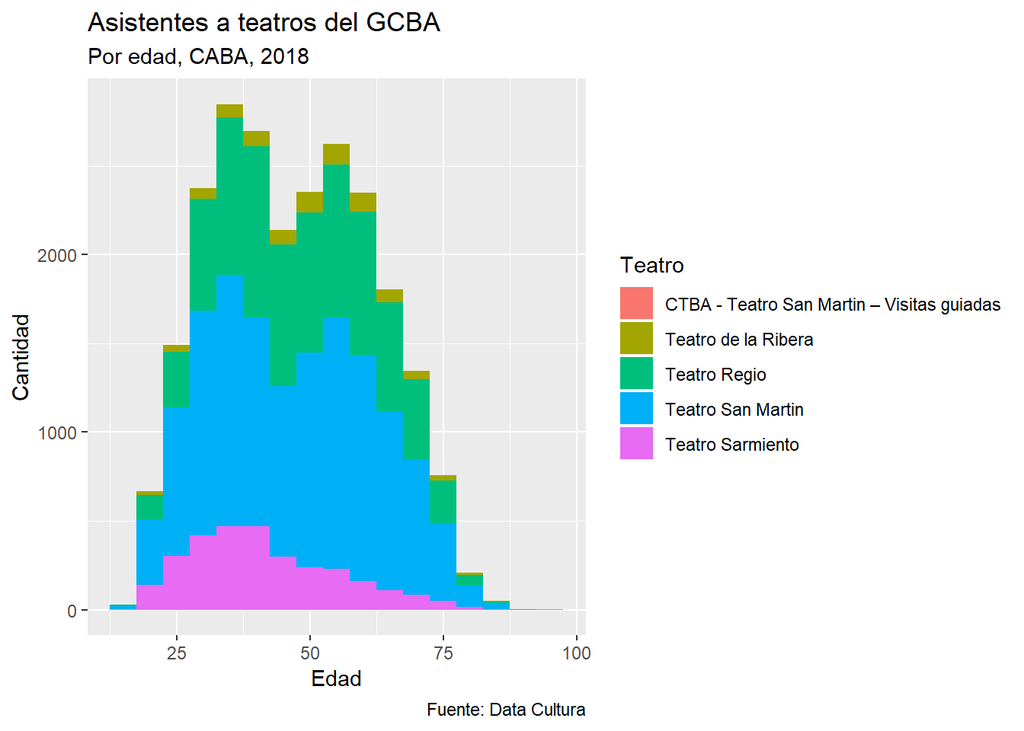

```r
ggplot(ctbaz, aes(x=edad,fill = teatro)) +
  geom_histogram(binwidth = 5) +
  labs(title = "Asistentes a teatros del GCBA",
         subtitle = "Por edad, CABA, 2018",
         caption = "Fuente: Data Cultura",
         x = "Edad",
         y = "Cantidad",
         fill = "Teatro")
```

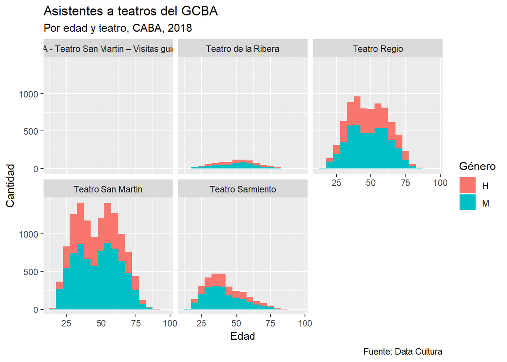

```r
ggplot(ctbaz, aes(x=edad, fill=Genero)) +
  geom_histogram(binwidth = 5) +
  facet_wrap(~teatro) +
  labs(title = "Asistentes a teatros del GCBA",
         subtitle = "Por edad y teatro, CABA, 2018",
         caption = "Fuente: Data Cultura",
         x = "Edad",
         y = "Cantidad",
         fill = "Género")
```

Por un lado es interesante notar que en general hay picos de asistencia entre el público de 30-40 años y de 55-65 años. Por otro lado, el Teatro Sarmiento y el de la Ribera presentan comportamientos específicos, el primero con público más jóven y el segundo más adulto. Esto se explica por el tipo de programación de estos teatros (más experimental, por un lado y más clásica, por el otro). No parecieran haber diferencias por género relacionadas con la edad.

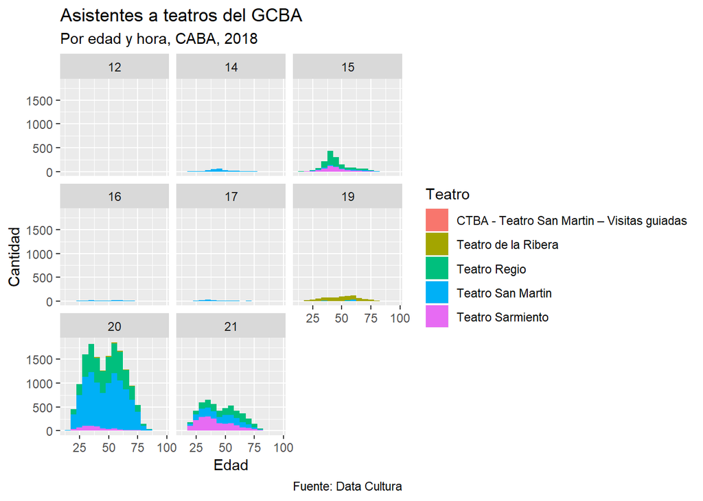

```r
ggplot(ctbaz, aes(x=edad, fill = teatro)) +
  geom_histogram(binwidth = 5) +
  facet_wrap(~hour(Dia)) +
  labs(title = "Asistentes a teatros del GCBA",
         subtitle = "Por edad y hora, CABA, 2018",
         caption = "Fuente: Data Cultura",
         x = "Edad",
         y = "Cantidad",
         fill = "Teatro")
```

Otro dato llamativo es que el público más jóven es el que asiste al teatro más temprano ( y no los jubilados como se suele suponer)

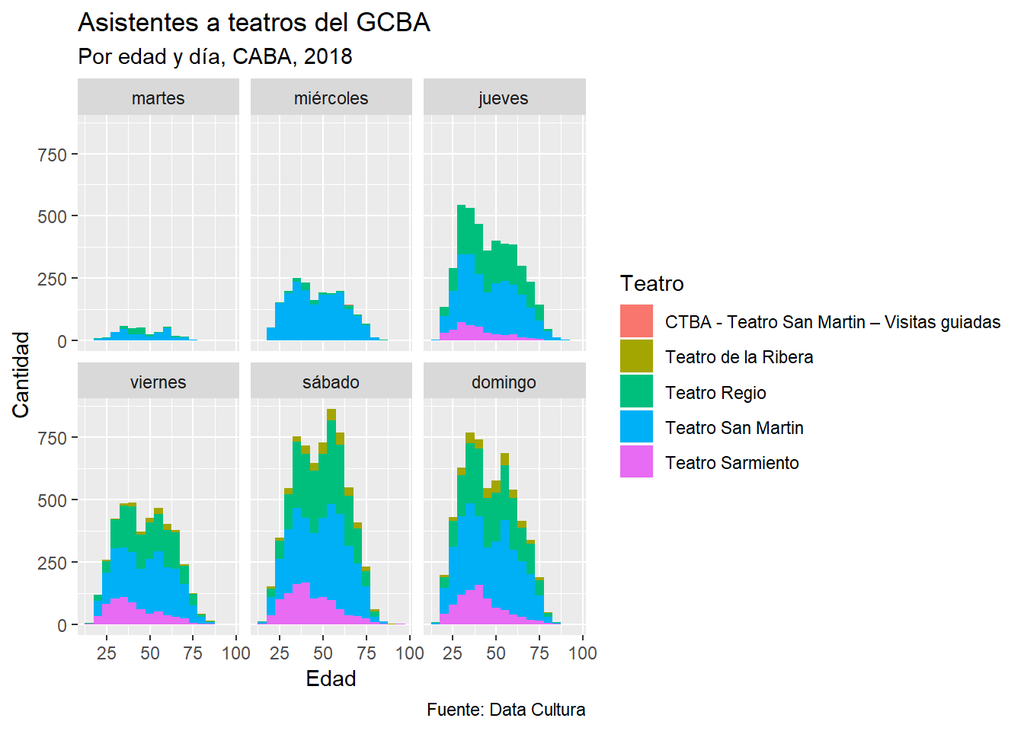

```r
ggplot(ctbaz, aes(x=edad, fill = teatro)) +
  geom_histogram(binwidth = 5) +
  facet_wrap(~wday(Dia, label=TRUE, abbr=FALSE, week_start = 2)) +
  labs(title = "Asistentes a teatros del GCBA",
         subtitle = "Por edad y día, CABA, 2018",
         caption = "Fuente: Data Cultura",
         x = "Edad",
         y = "Cantidad",
         fill = "Teatro")
```

Al analizar el dataset por día de la semana se observa que los treintañeros son los que más van los miercoles y los jueves, días que suelen presentar descuentos. Los sábados, por el contrario, crece la asistencis de gente de cerca de 60 años.

#### Asistencia de usuarios recurrentes

Otro dato que puede ser interesante de generar es el de cantidad de veces que fue cada usuario al teatro (esto es un estimativo, porque se computa quién realizó al transacción, por lo que una persona pudo haber ido más veces al teatro)

```r
ctbau <- ctbaz %>%
  group_by(Mail) %>%
  summarise (qus= n())

ctbau
```

```
## # A tibble: 16,711 x 2
##    Mail                           qus
##    <chr>                        <int>
##  1 100leguas@gmail.com              1
##  2 10pmrock@gmail.com               1
##  3 1948jaime08@gmail.com            1
##  4 1986nando@gmail.com              1
##  5 1camilamenendez@hotmail.com      1
##  6 1fitomendonca@gmail.com          1
##  7 1juanschnitman@gmail.com         3
##  8 1lucianapiantanida@gmail.com     1
##  9 1meugeniafontana@gmail.com       2
## 10 1serveraandrea@gmail.com         2
## # ... with 16,701 more rows
```

```r
ctbau %>%
  filter (qus==1) %>%
  summarise (q= n())
```

```
## # A tibble: 1 x 1
##       q
##   <int>
## 1 12928
```

```r
ctbau %>%
  filter (qus >1) %>%
  summarise (q= n(),
             visitas_promedio=mean(qus))
```

```
## # A tibble: 1 x 2
##       q visitas_promedio
##   <int>            <dbl>
## 1  3783             2.86
```

Y se la agrego al dataset

```r
ctbaz <- left_join(ctbaz, ctbau)
```

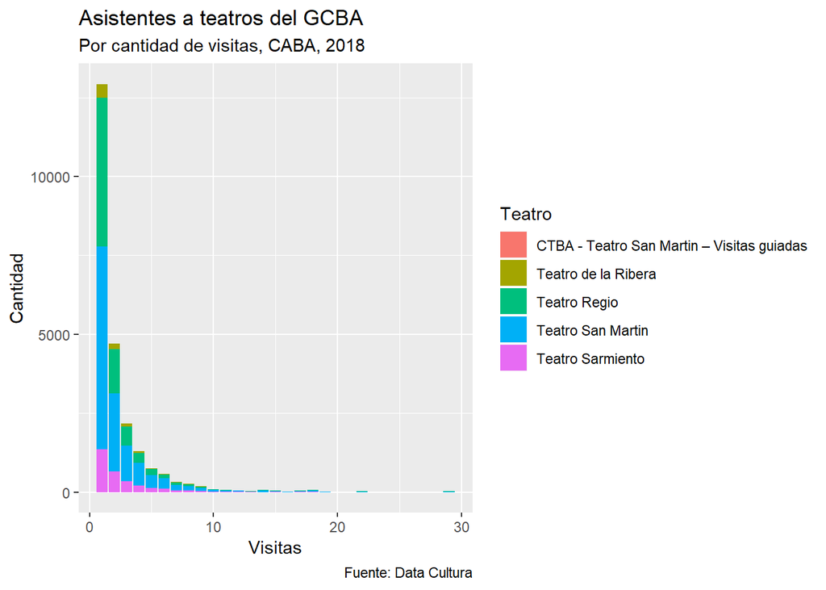

```r
ctbaz %>%
  ggplot() +
  geom_bar(aes(x=qus, fill = teatro)) +
  labs(title = "Asistentes a teatros del GCBA",
         subtitle = "Por cantidad de visitas, CABA, 2018",
         caption = "Fuente: Data Cultura",
         x = "Visitas",
         y = "Cantidad",
         fill = "Teatro")
```

Se genera además una variable dummy para ver si es un usuario recurrente o no.

Tambipen se genera una variable categórica para la edad (agrupada cada 5 años).

```r
ctbaz$recur <- cut(ctbaz$qus, c(0,1,30), labels=c("Asistentes ünicos", "Asistentes recurrentes"))

ctbaz$edadcat <- cut(ctbaz$edad, seq(15,90,5), right=FALSE)

str(ctbaz)
```

```
## Classes 'tbl_df', 'tbl' and 'data.frame':    23746 obs. of  16 variables:
##  $ Fecha de nac.        : Date, format: "1975-03-02" "1981-06-25" ...
##  $ Mail                 : chr  "agerlich75@gmail.com" "pato_u@hotmail.com" "pbarletta@gmail.com" "pbriuolo@gmail.com" ...
##  $ Genero               : chr  "H" "H" "H" "M" ...
##  $ Evento               : chr  "La vuelta al mundo en 80 mundos" "Madre coraje" "La vuelta al mundo en 80 mundos" "Blum" ...
##  $ Dia                  : POSIXct, format: "2018-07-21 15:00:00" "2018-12-01 21:00:00" ...
##  $ Lugar                : chr  "CTBA - Teatro Regio" "CTBA - Teatro Regio" "CTBA - Teatro Regio" "CTBA - Teatro Regio" ...
##  $ direccion_normalizada: chr  "COMBATE DE LOS POZOS 1138, CABA" "DIAZ VELEZ AV. 3841, CABA" "MOCTEZUMA 1036, CABA" "POTOSI 4052, CABA" ...
##  $ geometry             :sfc_POINT of length 23746; first list element:  'XY' num  -58.4 -34.6
##  $ barrio               : chr  "San Cristóbal" "Almagro" "Vélez Sarsfield" "Almagro" ...
##  $ comuna               : chr  "Comuna 3" "Comuna 5" "Comuna 10" "Comuna 5" ...
##  $ teatro               : chr  "Teatro Regio" "Teatro Regio" "Teatro Regio" "Teatro Regio" ...
##  $ fecha                : Date, format: "2018-07-21" "2018-12-01" ...
##  $ edad                 : num  43 37 28 67 41 36 28 48 61 65 ...
##  $ qus                  : int  1 2 1 4 1 3 7 1 1 2 ...
##  $ recur                : Factor w/ 2 levels "Asistentes ünicos",..: 1 2 1 2 1 2 2 1 1 2 ...
##  $ edadcat              : Factor w/ 15 levels "[15,20)","[20,25)",..: 6 5 3 11 6 5 3 7 10 11 ...
```

A continuación se compara el comportamiento de aquellas asistencias hechas por **asistentes únicos** (aquellos que realizaron una sola transacción) y aquellos **asistentes recurrentes** (aquellos que fueron más de una vez).

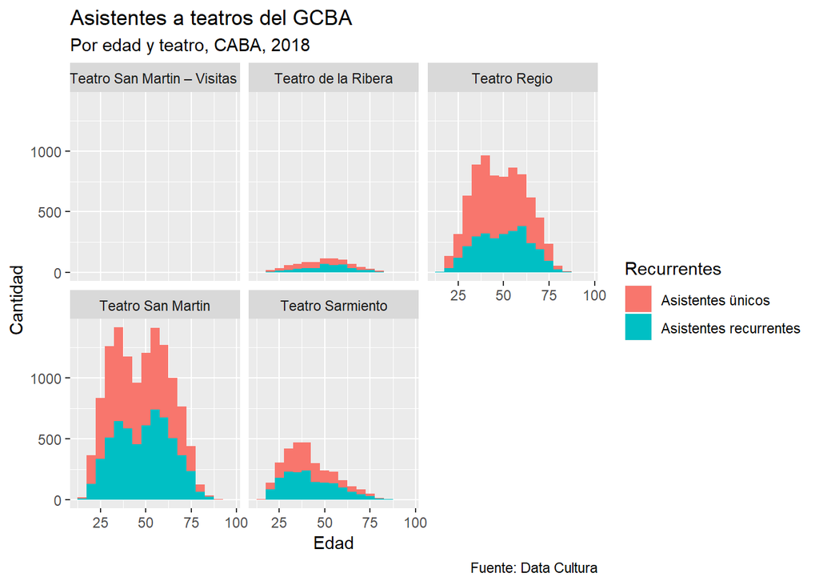

```r
ctbaz %>%
  ggplot(aes(x=edad, fill = recur)) +
  geom_histogram(binwidth = 5) +
  labs(title = "Asistentes a teatros del GCBA",
         subtitle = "Por edad y teatro, CABA, 2018",
         caption = "Fuente: Data Cultura",
         x = "Edad",
         y = "Cantidad",
         fill = "Recurrentes")+
  facet_wrap (~teatro)
```

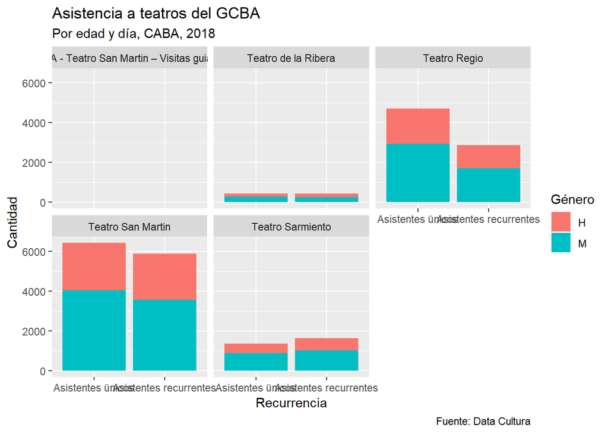

```r
ctbaz %>%
  ggplot()+
  geom_bar(aes(x=recur, fill=Genero)) +
  facet_wrap(~teatro) +
  labs(title = "Asistencia a teatros del GCBA",
         subtitle = "Por edad y día, CABA, 2018",
         caption = "Fuente: Data Cultura",
         x = "Recurrencia",
         y = "Cantidad",
         fill = "Género")
```

```r
ctbaz$recur <- as.numeric(ctbaz$recur)

ctbaz %>%
  group_by(teatro) %>%
  summarise (tasa_recur = mean(recur) - 1)
```

```
## # A tibble: 5 x 2
##   teatro                                     tasa_recur
##   <chr>                                           <dbl>
## 1 CTBA - Teatro San Martin  Visitas guiadas      1
## 2 Teatro de la Ribera                             0.495
## 3 Teatro Regio                                    0.379
## 4 Teatro San Martin                               0.478
## 5 Teatro Sarmiento                                0.545
```

A partir de los gráficos se pueden observar diferencias por edad que se analizarán más adelante. Por otro lado, mientras que el 38% de las transacciones hechas en el Teatro Regio fue por asistentes recurrentes, el Sarmiento tuvo un 55% de tasa de recurrencia (esto es, más de las mitad de las transacciones que se hicieron por internet fue de gente que asistió más de una vez a algún teatro del GCBA).

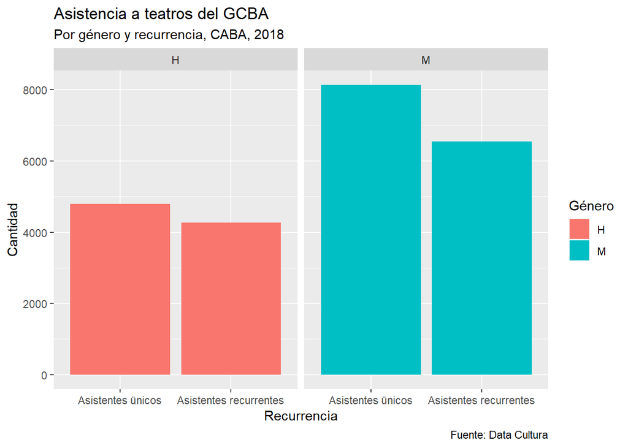

```r
ctbaz$recur <- cut(ctbaz$qus, c(0,1,30), labels=c("Asistentes ünicos", "Asistentes recurrentes"))

ctbaz %>%
  ggplot()+
  geom_bar(aes(x=recur, fill = Genero)) +
  facet_wrap(~Genero) +
  labs(title = "Asistencia a teatros del GCBA",
         subtitle = "Por género y recurrencia, CABA, 2018",
         caption = "Fuente: Data Cultura",
         x = "Recurrencia",
         y = "Cantidad",
         fill = "Género")
```

```r
ctbaz$recur <- as.numeric (ctbaz$recur)

ctbaz %>%
  group_by(Genero) %>%
  summarise(tasa_recur = mean(recur) -1)
```

```
## # A tibble: 2 x 2
##   Genero tasa_recur
##   <chr>       <dbl>
## 1 H           0.471
## 2 M           0.446
```

Los hombres presentan una tasa de recurrencia mayor que las mujeres (47% frente a 45%). Entonces se puede decir que los hombres que asisten al teatro, como son menos en el total de transacciones, son un núcleo intenso de asistentes.

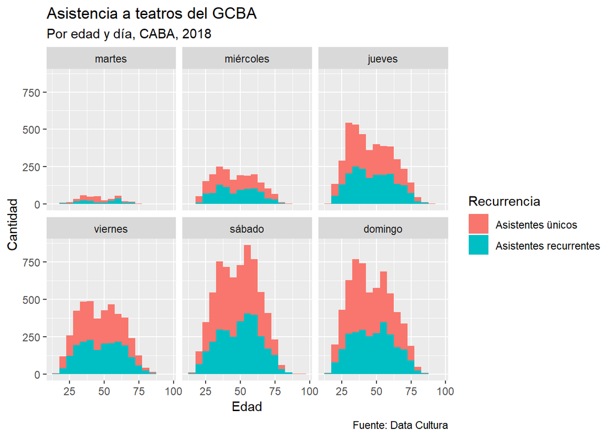

```r
ctbaz$recur <- cut(ctbaz$qus, c(0,1,30), labels=c("Asistentes ünicos", "Asistentes recurrentes"))

ctbaz %>%
  ggplot(aes(x=edad, fill = recur)) +
  facet_wrap(~wday(Dia, label=TRUE, abbr=FALSE, week_start = 2)) +
  geom_histogram(binwidth = 5) +
  labs(title = "Asistencia a teatros del GCBA",
         subtitle = "Por edad y día, CABA, 2018",
         caption = "Fuente: Data Cultura",
         x = "Edad",
         y = "Cantidad",
         fill = "Recurrencia")
```

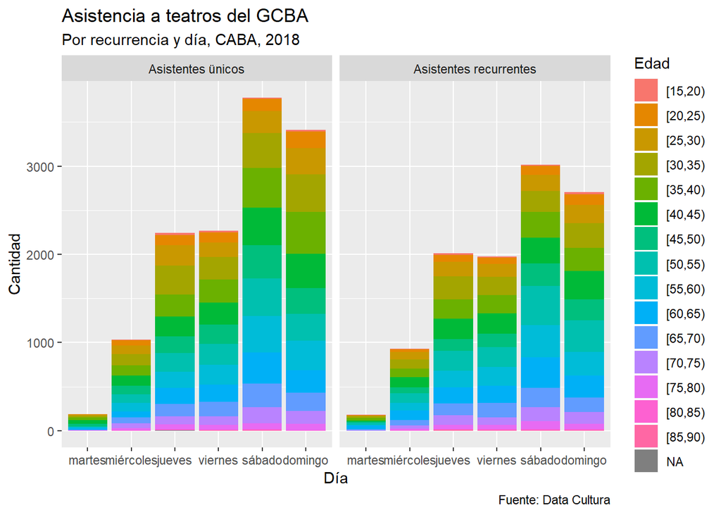

```r
ctbaz %>%
  ggplot()+
  geom_bar(aes(x=wday(Dia, label=TRUE, abbr=FALSE, week_start = 2), fill = edadcat)) +
  facet_wrap(~recur) +
  labs(title = "Asistencia a teatros del GCBA",
         subtitle = "Por recurrencia y día, CABA, 2018",
         caption = "Fuente: Data Cultura",
         x = "Día",
         y = "Cantidad",
         fill = "Edad")
```

```r
ctbaz$recur <- as.numeric(ctbaz$recur)

ctbaz %>%
  group_by(pordia=wday(Dia, label=TRUE, abbr=FALSE, week_start = 2)) %>%
  summarise(tasa_recur = mean(recur)-1)
```

```
## # A tibble: 6 x 2
##   pordia    tasa_recur
##   <ord>          <dbl>
## 1 martes         0.489
## 2 miércoles      0.473
## 3 jueves         0.473
## 4 viernes        0.466
## 5 sábado         0.444
## 6 domingo        0.442
```

Al analizar la recurrencia por día, se observa que el martes es el día de los que asisten seguido al teatro, casí la mitad (49%) de las asistencias es de público recurrente. Por el contrario, el fin de semana es del público más casual (tasa de recurrencia en torno al 44%). A su vez, se puede ver que esta tendencia se acrecienta entre los más jóvenes.

```r
ctbaz <- mutate(ctbaz, recur= recur-1)
```

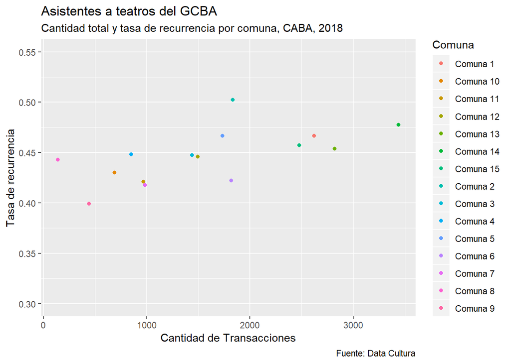

```r
ctbaz %>%
  group_by(comuna) %>%
  summarise(tasa_recur = mean(recur),
            asist = n()) %>%
  ggplot() +
  geom_point(aes(x= asist , y=tasa_recur, colour=comuna)) +
  labs(title = "Asistentes a teatros del GCBA",
         subtitle = "Cantidad total y tasa de recurrencia por comuna, CABA, 2018",
         caption = "Fuente: Data Cultura",
         x = "Cantidad de Transacciones",
         y = "Tasa de recurrencia",
         colour = "Comuna") +
  ylim(c(0.3, 0.55))
```

```r
ctbacomr <- ctbaz %>%
  group_by(comuna) %>%
  summarise(tasa_recur = mean(recur),
            asist = n()/1000)

ctbacomr <- as.data.frame(ctbacomr)

lmcomr <- lm(tasa_recur ~ asist, ctbacomr)

summary(lmcomr)
```

```
##
## Call:
## lm(formula = tasa_recur ~ asist, data = ctbacomr)
##
## Residuals:
##       Min        1Q    Median        3Q       Max
## -0.028453 -0.014516 -0.000874  0.008817  0.051604
##
## Coefficients:
##             Estimate Std. Error t value Pr(>|t|)
## (Intercept) 0.419479   0.011119  37.726 1.14e-14 ***
## asist       0.017115   0.006086   2.812   0.0147 *
## ---
## Signif. codes:  0 '***' 0.001 '**' 0.01 '*' 0.05 '.' 0.1 ' ' 1
##
## Residual standard error: 0.0215 on 13 degrees of freedom
## Multiple R-squared:  0.3783, Adjusted R-squared:  0.3305
## F-statistic:  7.91 on 1 and 13 DF,  p-value: 0.01468
```

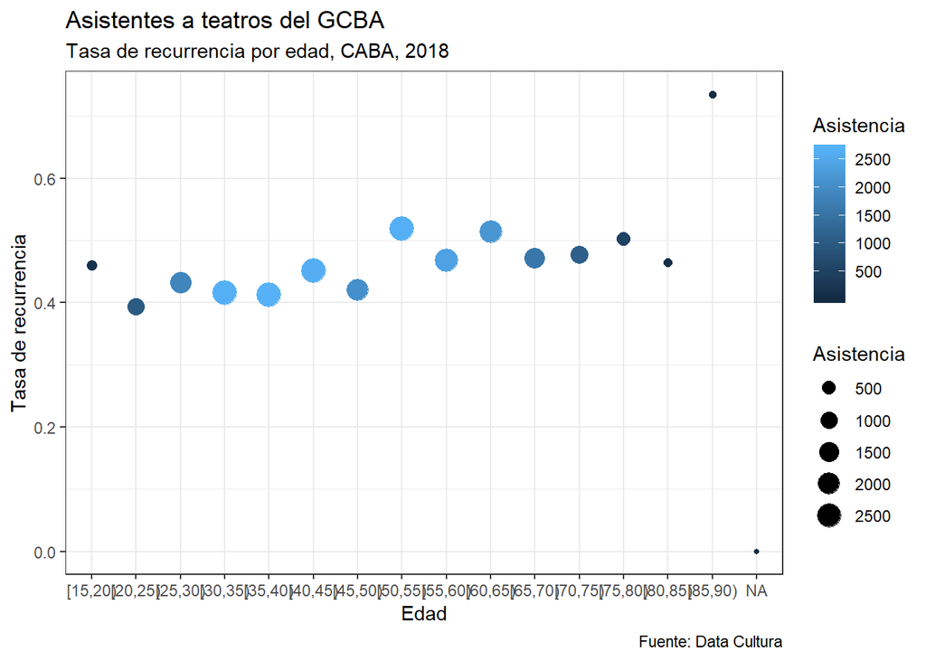

```r
ctbaz %>%
  group_by(edadcat) %>%
  summarise(tasa_recur = mean(recur),
            asist=n()) %>%
  ggplot() +
  geom_point(aes(x= edadcat, y=tasa_recur, size=asist, colour=asist)) +
  labs(title = "Asistentes a teatros del GCBA",
         subtitle = "Tasa de recurrencia por edad, CABA, 2018",
         caption = "Fuente: Data Cultura",
         x = "Edad",
         y = "Tasa de recurrencia",
         size = "Asistencia",
       colour="Asistencia") +
  theme_bw()
```

```r
ctbaedadr <- ctbaz %>%
  group_by(edadcat) %>%
  summarise(tasa_recur = mean(recur))

ctbaedadr$edadcat <- as.numeric(ctbaedadr$edadcat)

ctbaedadr <- as.data.frame(ctbaedadr)

lmedadr <- lm(tasa_recur ~ edadcat, ctbaedadr)

summary(lmedadr)
```

```
##
## Call:
## lm(formula = tasa_recur ~ edadcat, data = ctbaedadr)
##
## Residuals:
##      Min       1Q   Median       3Q      Max
## -0.08152 -0.03583 -0.01267  0.01532  0.17689
##
## Coefficients:
##             Estimate Std. Error t value Pr(>|t|)
## (Intercept) 0.381798   0.034664  11.014  5.8e-08 ***
## edadcat     0.011774   0.003813   3.088  0.00864 **
## ---
## Signif. codes:  0 '***' 0.001 '**' 0.01 '*' 0.05 '.' 0.1 ' ' 1
##
## Residual standard error: 0.0638 on 13 degrees of freedom
##   (1 observation deleted due to missingness)
## Multiple R-squared:  0.4232, Adjusted R-squared:  0.3788
## F-statistic: 9.537 on 1 and 13 DF,  p-value: 0.008641
```

Al graficar la tasa de recurrencia por grupo etáreo se observa que esta va en aumento a medida que la población es mayor. Un análisis de regresión lineal demuestra que existe esta vinculación (la variable edadcat es significativa) y que cada 5 años aumenta un 0,01 la tasa de recurrencia. Al parecer, ir recurrentemente al teatro del GCBA es una costumbre que se incrementa a medida que pasa el tiempo.

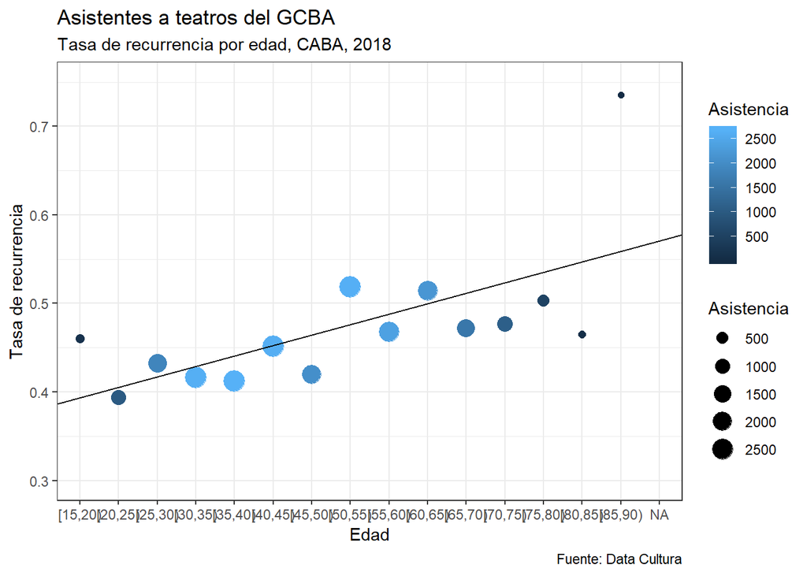

```r
ctbaz %>%
  group_by(edadcat) %>%
  summarise(tasa_recur = mean(recur),
            asist=n()) %>%
  ggplot() +
  geom_point(aes(x= edadcat, y=tasa_recur, size=asist, colour=asist)) +
  labs(title = "Asistentes a teatros del GCBA",
         subtitle = "Tasa de recurrencia por edad, CABA, 2018",
         caption = "Fuente: Data Cultura",
         x = "Edad",
         y = "Tasa de recurrencia",
         size = "Asistencia",
       colour="Asistencia") +
  theme_bw() +
  geom_abline(aes(intercept = 0.381750 , slope = 0.011778 )) +
  ylim(c(0.3, 0.75))
```

### Análisis espaciales

#### Espacios escénicos

Ahora se desea observar cómo se vincula este dataset con otra información, en este caso con la cantidad cantidad de espacios culturales teatrales. Se desea observar si existe relación entre la cantidad de teatros en un barrio y la cantidad de gente del barrio que va al teatro. Si bien la base es de teatro público, se supone que los que asisten al teatro privado, también asisten al teatro público, por lo que se busca ver si existe relación entre la ubicación entre los usuarios y los teatros.

```r
cult <- read_sf('C:/Users/Claudia/Documents/R/GCBA Datos/Taller CABA/dependencias_culturales.shp')

summary(cult)
```

```
##        id            nombre             calle1             calle2
##  Min.   :   1.0   Length:2096        Length:2096        Length:2096
##  1st Qu.: 537.8   Class :character   Class :character   Class :character
##  Median :1088.5   Mode  :character   Mode  :character   Mode  :character
##  Mean   :1086.9
##  3rd Qu.:1638.2
##  Max.   :2174.0
##      altura          piso              depto            codigo_pos
##  Min.   :    0   Length:2096        Length:2096        Length:2096
##  1st Qu.:  649   Class :character   Class :character   Class :character
##  Median : 1330   Mode  :character   Mode  :character   Mode  :character
##  Mean   : 1751
##  3rd Qu.: 2374
##  Max.   :11450
##   direccion            barrio             comuna
##  Length:2096        Length:2096        Length:2096
##  Class :character   Class :character   Class :character
##  Mode  :character   Mode  :character   Mode  :character
##
##
##
##   actividad_         otras_acti         dias_y_hor
##  Length:2096        Length:2096        Length:2096
##  Class :character   Class :character   Class :character
##  Mode  :character   Mode  :character   Mode  :character
##
##
##
##   telefonos           celular             email
##  Length:2096        Length:2096        Length:2096
##  Class :character   Class :character   Class :character
##  Mode  :character   Mode  :character   Mode  :character
##
##
##
##   pagina_web         dependenci          publico
##  Length:2096        Length:2096        Length:2096
##  Class :character   Class :character   Class :character
##  Mode  :character   Mode  :character   Mode  :character
##
##
##
##     sector                   geometry
##  Length:2096        POINT        :2096
##  Class :character   epsg:NA      :   0
##  Mode  :character   +proj=tmer...:   0
##
##
##
```

Se dejan sólo las variabels con las que interesa trabajar

```r
cult <- select(cult, nombre, actividad_, publico, sector, geometry, barrio, comuna)

summary(cult)
```

```
##     nombre           actividad_          publico
##  Length:2096        Length:2096        Length:2096
##  Class :character   Class :character   Class :character
##  Mode  :character   Mode  :character   Mode  :character
##     sector             barrio             comuna
##  Length:2096        Length:2096        Length:2096
##  Class :character   Class :character   Class :character
##  Mode  :character   Mode  :character   Mode  :character
##           geometry
##  POINT        :2096
##  epsg:NA      :   0
##  +proj=tmer...:   0
```

Se observan las actividades presentes en el dataset:

```r
table (cult$actividad_)
```

```
##
##                                      Archivo
##                                           15
##                                 Bar Cultural
##                                           16
##                                 Bar Elemento
##                                           32
##                             Bar Identificado
##                                           53
##                                  Bar Notable
##                                           72
##                                   Biblioteca
##                                          216
##                                     Calesita
##                                           50
##                              Centro Cultural
##                                          103
##                                         Cine
##                                           26
##                                        Circo
##                                            1
##                                    Disquería
##                                           62
##                                    Editorial
##                                          224
##                             Espacio Cultural
##                                            7
## Espacio de Formación (Seminarios y Talleres)
##                                          138
##    Espacio Escénico (Teatro, Música y Danza)
##                                          219
##                              Galería de Arte
##                                           72
##                                     Librería
##                                          442
##                        Milonga y/o Tanguería
##                                           68
##                                        Museo
##                                          131
##                                         Peña
##                                            4
##                                   Planetario
##                                            1
##                       Productora Audiovisual
##                                           55
##                        Radio Local (AM y FM)
##                                           38
##                           Sala de Exposición
##                                            7
##                           Sello Discográfico
##                                           39
##                             Televisión Local
##                                            5
```

Como hay muchos tipos de espacios, se seleccionan sólo los de espacios escénicos, que son los que interesa trabajar.

```r
cultea <- filter (cult, actividad_ == "Espacio Escénico (Teatro, Música y Danza)" )
```

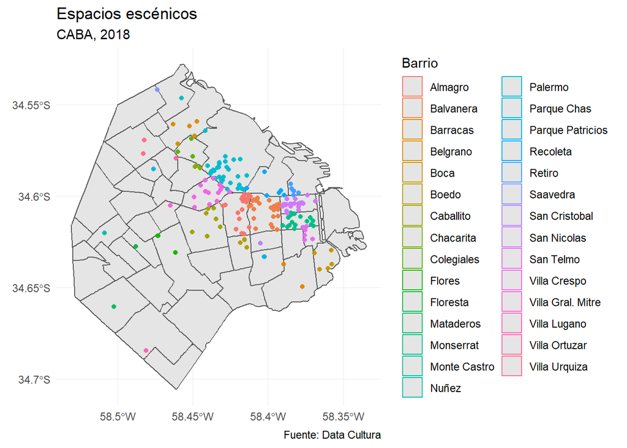

```r
ggplot() +
  geom_sf(data=barrios) +
  geom_sf(data = cultea, aes(colour = barrio))+
  labs(title = "Espacios escénicos",
         subtitle = "CABA, 2018",
         caption = "Fuente: Data Cultura",
         colour = "Barrio") +
  theme_minimal () +
  coord_sf(crs = st_crs(4326))
```

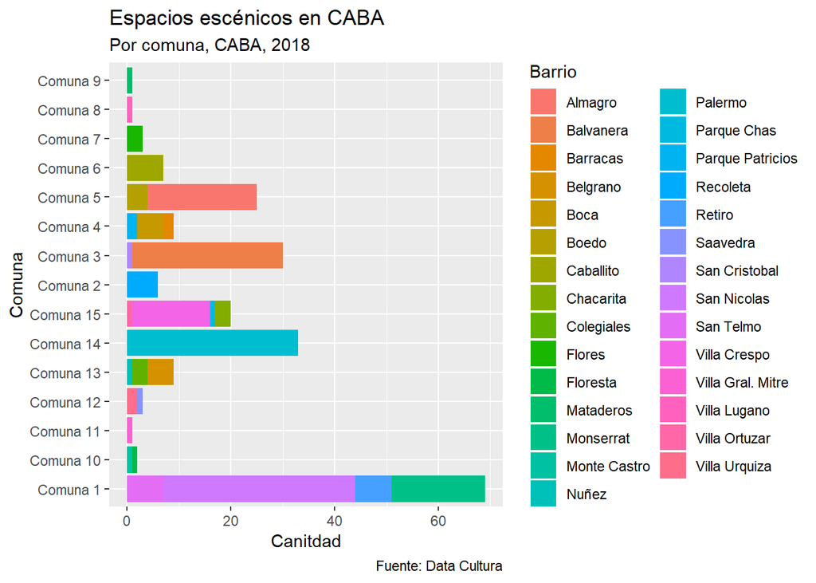

```r
ggplot(cultea) +
  geom_bar(aes(x= comuna, fill = barrio )) +
  labs(title = "Espacios escénicos en CABA",
         subtitle = "Por comuna, CABA, 2018",
         caption = "Fuente: Data Cultura",
         x = "Comuna",
         y = "Canitdad",
         fill = "Barrio") +
   coord_flip()
```

Se observa una gran concentración de espacios en la comuna 1, en segundo lugar en Comuna 14, seguido por comuna 3 y 5.

Se desea realizar un spatial join, entre los espacios y los barrios. Primero se chequea que tengan la misma proyeccion

```r
colnames(barrios)[1] <- "barrio"

cultea$barrio <- toupper(cultea$barrio)

as.data.frame(cultea)
```

[output not shown]

[output cut: 865 more lines]

```r
cultea_bar <- cultea %>%
  select (barrio) %>%
  group_by (barrio) %>%
  summarise(q = n())

cultea_bar <- st_transform(cultea_bar, 4326)

cultea <- st_transform(cultea, 4326)

barrios1 <- st_join(barrios, cultea_bar)

str(barrios1)
```

```
## Classes 'sf' and 'data.frame':   48 obs. of  7 variables:
##  $ barrio.x : Factor w/ 48 levels "AGRONOMIA","ALMAGRO",..: 9 26 36 37 2 8 46 18 44 13 ...
##  $ COMUNA   : Factor w/ 15 levels "1","10","11",..: 7 7 7 3 11 12 3 2 2 13 ...
##  $ PERIMETRO: Factor w/ 48 levels "10021.45966480549",..: 41 36 43 40 46 5 26 37 22 13 ...
##  $ AREA     : Factor w/ 48 levels "1232275.092474457",..: 22 14 25 24 28 42 11 21 3 46 ...
##  $ barrio.y : chr  "CHACARITA" NA "VILLA CRESPO" NA ...
##  $ q        : int  3 NA 15 NA 21 7 NA 1 NA 3 ...
##  $ geometry :sfc_POLYGON of length 48; first list element: List of 1
##   ..$ : num [1:572, 1:2] -58.5 -58.5 -58.5 -58.5 -58.5 ...
##   ..- attr(*, "class")= chr  "XY" "POLYGON" "sfg"
##  - attr(*, "sf_column")= chr "geometry"
##  - attr(*, "agr")= Factor w/ 3 levels "constant","aggregate",..: NA NA NA NA NA NA
##   ..- attr(*, "names")= chr  "barrio.x" "COMUNA" "PERIMETRO" "AREA" ...
```

Se limpia la variable duplicada:

```r
colnames(barrios1)[1] <- "barrio"

barrios1 <- select (barrios1, -barrio.y)
```

Grafico

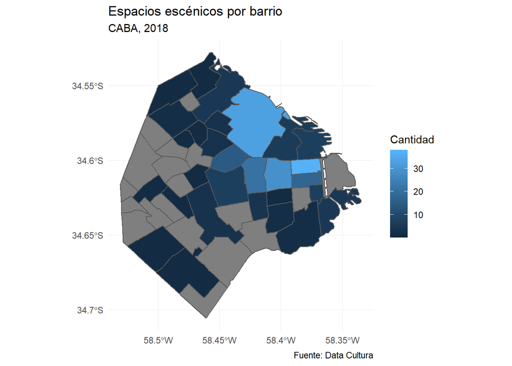

```r
ggplot() +
  geom_sf(data=barrios1, aes(fill=q)) +
  theme_minimal() +
  coord_sf(crs = st_crs(4326)) +
  labs(title = "Espacios escénicos por barrio",
         subtitle = "CABA, 2018",
         caption = "Fuente: Data Cultura",
         fill = "Cantidad")
```

Ahora que tengo la cantidad de teatros por barrios, quiero traer la cantidad de asistentes al teatro por barrio.

```r
ctbaz$barrio <- toupper(ctbaz$barrio)
table(ctbaz$barrio)
```

```
##
##         AGRONOMÍA           ALMAGRO         BALVANERA          BARRACAS
##                95              1428              1105               324
##          BELGRANO              BOCA             BOEDO         CABALLITO
##              1497               191               304              1817
##         CHACARITA           COGHLAN        COLEGIALES      CONSTITUCIÓN
##               540               247               781               267
##            FLORES          FLORESTA           LINIERS         MATADEROS
##               655               179               115               180
##         MONSERRAT      MONTE CASTRO     NUEVA POMPEYA             NUÑEZ
##               595                98               101               543
##           PALERMO PARQUE AVELLANEDA  PARQUE CHACABUCO       PARQUE CHAS
##              3439               146               329               172
##  PARQUE PATRICIOS          PATERNAL     PUERTO MADERO          RECOLETA
##               234               129               106              1833
##            RETIRO          SAAVEDRA     SAN CRISTÓBAL       SAN NICOLÁS
##               489               364               334               808
##         SAN TELMO   VÉLEZ SARSFIELD         VERSALLES      VILLA CRESPO
##               355               168                50              1240
##  VILLA DEL PARQUE      VILLA DEVOTO VILLA GRAL. MITRE      VILLA LUGANO
##               306               279               205               108
##        VILLA LURO     VILLA ORTÚZAR  VILLA PUEYRREDÓN        VILLA REAL
##               136               303               188                57
##   VILLA RIACHUELO  VILLA SANTA RITA     VILLA SOLDATI     VILLA URQUIZA
##                11               179                21               695
```

```r
ctbaz$barrio %>%
  gsub("Á", "A", ctbaz$barrio) %>%
  gsub("É", "E", ctbaz$barrio) %>%
  gsub("Í", "I", ctbaz$barrio) %>%
  gsub("Ó", "O", ctbaz$barrio) %>%
  gsub("Ú", "U", ctbaz$barrio)
```

```
## [1] "U"
```

```r
table(ctbaz$barrio)
```

```
##
##         AGRONOMÍA           ALMAGRO         BALVANERA          BARRACAS
##                95              1428              1105               324
##          BELGRANO              BOCA             BOEDO         CABALLITO
##              1497               191               304              1817
##         CHACARITA           COGHLAN        COLEGIALES      CONSTITUCIÓN
##               540               247               781               267
##            FLORES          FLORESTA           LINIERS         MATADEROS
##               655               179               115               180
##         MONSERRAT      MONTE CASTRO     NUEVA POMPEYA             NUÑEZ
##               595                98               101               543
##           PALERMO PARQUE AVELLANEDA  PARQUE CHACABUCO       PARQUE CHAS
##              3439               146               329               172
##  PARQUE PATRICIOS          PATERNAL     PUERTO MADERO          RECOLETA
##               234               129               106              1833
##            RETIRO          SAAVEDRA     SAN CRISTÓBAL       SAN NICOLÁS
##               489               364               334               808
##         SAN TELMO   VÉLEZ SARSFIELD         VERSALLES      VILLA CRESPO
##               355               168                50              1240
##  VILLA DEL PARQUE      VILLA DEVOTO VILLA GRAL. MITRE      VILLA LUGANO
##               306               279               205               108
##        VILLA LURO     VILLA ORTÚZAR  VILLA PUEYRREDÓN        VILLA REAL
##               136               303               188                57
##   VILLA RIACHUELO  VILLA SANTA RITA     VILLA SOLDATI     VILLA URQUIZA
##                11               179                21               695
```

Se crea un nuevo dataset agregado por barrio y se lo une con el de barrios

```r
ctbaz <- as_data_frame (ctbaz)

ctbay <- ctbaz %>%
  select (barrio) %>%
  group_by (barrio) %>%
  summarise(t = n())

ctbay <- as.data.frame(ctbay)

barctba <- left_join(barrios1, ctbay)

summary(barctba)
```

```
##     barrio              COMUNA               PERIMETRO
##  Length:48          1      : 6   10021.45966480549: 1
##  Class :character   10     : 6   10165.62712936149: 1
##  Mode  :character   15     : 6   10597.25280900626: 1
##                     11     : 4   10674.41646756023: 1
##                     12     : 4   10990.96447148555: 1
##                     4      : 4   11124.63579209356: 1
##                     (Other):18   (Other)          :42
##                 AREA          q                t
##  1232275.092474457: 1   Min.   : 1.000   Min.   :  11.0
##  1279951.372561846: 1   1st Qu.: 1.000   1st Qu.: 136.0
##  1334146.08283464 : 1   Median : 3.000   Median : 279.0
##  1385411.513739759: 1   Mean   : 7.552   Mean   : 526.4
##  1406833.595801687: 1   3rd Qu.: 7.000   3rd Qu.: 595.0
##  15772496.3315    : 1   Max.   :37.000   Max.   :3439.0
##  (Other)          :42   NA's   :19       NA's   :7
##           geometry
##  POLYGON      :48
##  epsg:4326    : 0
##  +proj=long...: 0
##
##
##
##
```

Se grafica el nuevo dataset

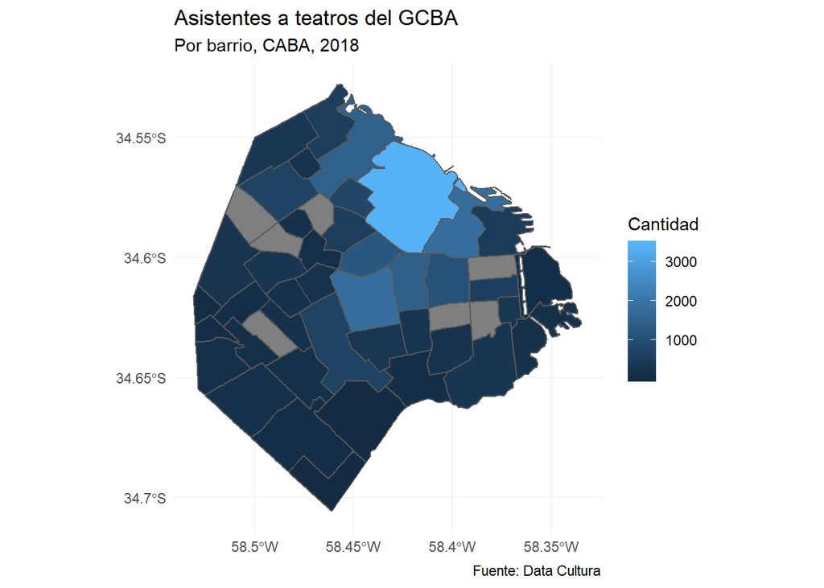

```r
ggplot() +
  geom_sf(data=barctba, aes(fill=t)) +
  theme_minimal() +
  coord_sf(crs = st_crs(4326)) +
  labs(title = "Asistentes a teatros del GCBA",
         subtitle = "Por barrio, CABA, 2018",
         caption = "Fuente: Data Cultura",
         fill = "Cantidad")
```

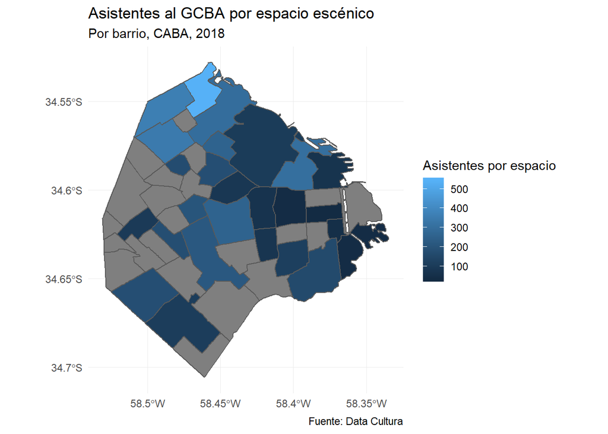

```r
ggplot() +
  geom_sf(data=barctba, aes(fill=t/q)) +
  theme_minimal() +
  coord_sf(crs = st_crs(4326)) +
  labs(title = "Asistentes al GCBA por espacio escénico",
         subtitle = "Por barrio, CABA, 2018",
         caption = "Fuente: Data Cultura",
         fill = "Asistentes por espacio")
```

Como una forma de normalizar los datos, se observa el ratio de asistentes por espacio. Se ve más homogeneizado, por lo que podría existir vinculación.

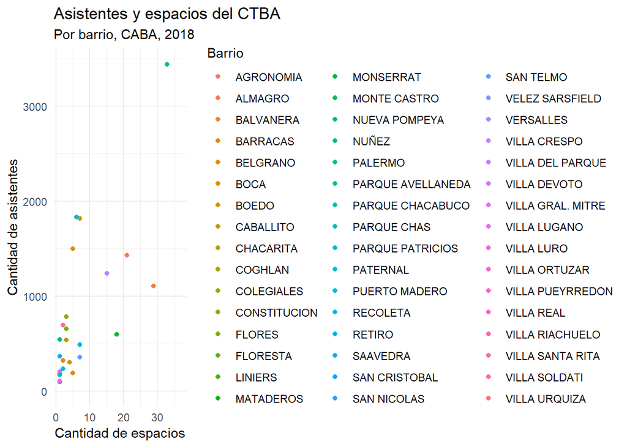

```r
ggplot(data = barctba) +
  geom_point(aes(x = t, y = q, color = barrio)) +
    labs(title = "Asistentes y espacios del CTBA",
         subtitle = "Por barrio, CABA, 2018",
         x = "Cantidad de asistentes",
         y = "Cantidad de espacios",
         color= "Barrio") +
  coord_flip() +
  theme_minimal()
```

```r
mlqtbar<- lm(q ~ t, barctba)

summary(mlqtbar)
```

```
##
## Call:
## lm(formula = q ~ t, data = barctba)
##
## Residuals:
##    Min     1Q Median     3Q    Max
## -9.948 -3.073 -1.199  2.555 19.091
##
## Coefficients:
##             Estimate Std. Error t value  Pr(>|t|)
## (Intercept) 0.742854   1.762993   0.421     0.677
## t           0.008295   0.001671   4.963 0.0000456 ***
## ---
## Signif. codes:  0 '***' 0.001 '**' 0.01 '*' 0.05 '.' 0.1 ' ' 1
##
## Residual standard error: 6.364 on 24 degrees of freedom
##   (22 observations deleted due to missingness)
## Multiple R-squared:  0.5065, Adjusted R-squared:  0.486
## F-statistic: 24.64 on 1 and 24 DF,  p-value: 0.0000456
```

Un siguiente análisis consiste en observar cuán lejos viven los asistentes de cada teatro de este. Para ello, se toma el set de espacios teatrales que tiene la información georreferenciada para cada espacio (de aqui interesan los teatros del GCBA) y se la une con la base de transacciones del CTBA. Posteriormente, se calcula la distancia espacial entre el teatro y el domicilio de la transacción.

```r
cultea$nombre <- cultea$nombre %>%
  str_replace ("Teatro General San Martín", "Teatro San Martin")

ctbatea <- left_join(ctbaz, cultea, by = c("teatro" = "nombre"))

ctbatea$dist <- st_distance(ctbatea$geometry.x,ctbatea$geometry.y, by_element=TRUE)

ctbatea$dist <- as.numeric(ctbatea$dist)
```

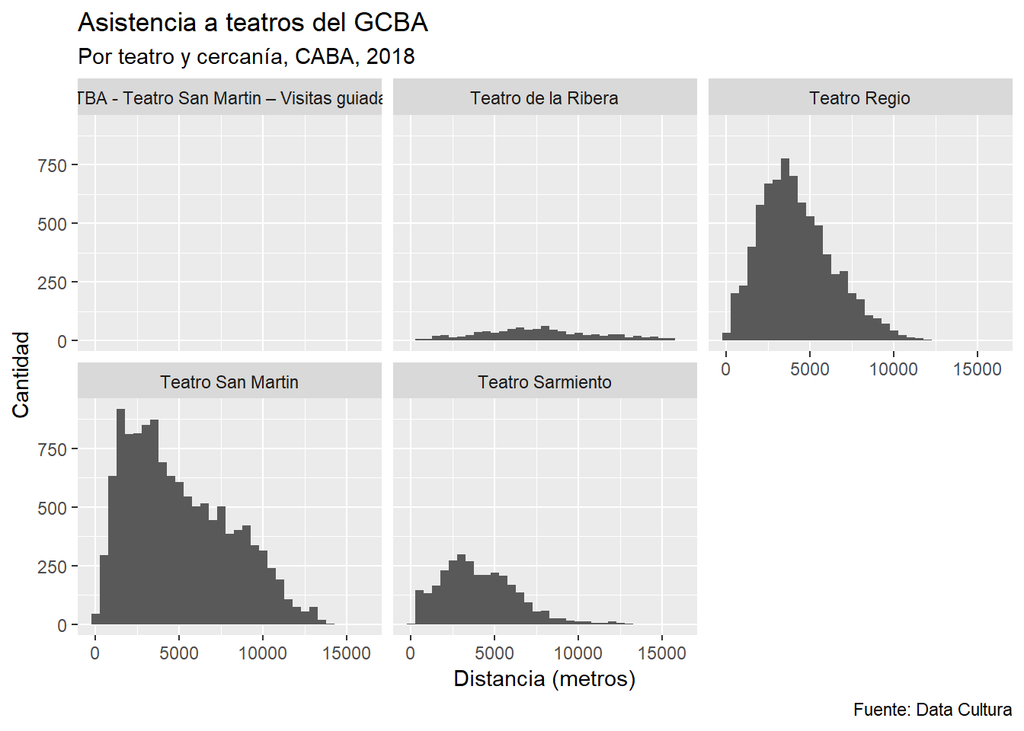

```r
ctbatea %>%
  ggplot(aes(x=dist)) +
  facet_wrap(~teatro) +
  geom_histogram(binwidth = 500) +
  labs(title = "Asistencia a teatros del GCBA",
         subtitle = "Por teatro y cercanía, CABA, 2018",
         caption = "Fuente: Data Cultura",
         x = "Distancia (metros)",
         y = "Cantidad")
```

Se observa un comportamiento similar para la mayoría de los teatros, que aumenta rápidamente y después disminuye.

```r
ctbatea <- mutate (ctbatea, km=dist/1000)
ctbatea$km <- cut(ctbatea$km, seq(0,50,1))
ctbatea$km <- as.numeric(ctbatea$km)
```

[figure not shown]

```r
ctbatea %>%
  ggplot() +
  geom_bar(aes(x=km, fill=teatro) )+
  labs(title = "Asistencia a teatros del GCBA",
         subtitle = "Por edad y día, CABA, 2018",
         caption = "Fuente: Data Cultura",
         x = "Edad",
         y = "Cantidad",
         fill = "Recurrencia")
```

```r
colnames(ctbatea)[8] <- "geometry"
```

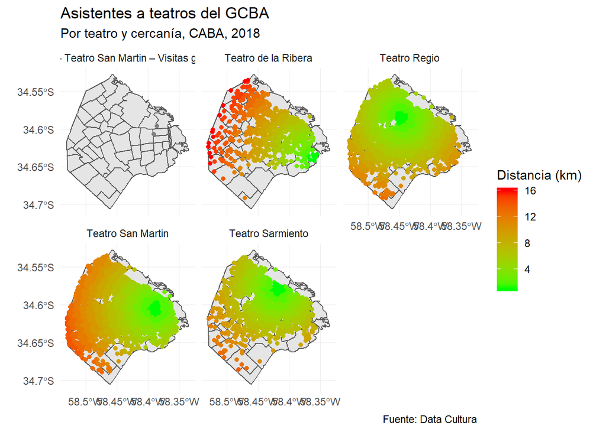

```r
ggplot() +
  geom_sf(data=barrios) +
  geom_sf(data=ctbatea, aes (colour = km)) +
  scale_colour_gradient(low='green', high = 'red') +
  coord_sf(crs = st_crs(4326)) +
  labs(title = "Asistentes a teatros del GCBA",
         subtitle = "Por teatro y cercanía, CABA, 2018",
         caption = "Fuente: Data Cultura",
         colour = "Distancia (km)") +
  facet_wrap(~teatro) +
  theme_minimal()
```

```r
ctbatea1 <- ctbatea %>%
  group_by(km) %>%
  summarise(asist=n())

ctbatea1 <- as.data.frame(ctbatea1)

lmdist <- lm(asist ~ km, ctbatea1)

summary(lmdist)
```

```
##
## Call:
## lm(formula = asist ~ km, data = ctbatea1)
##
## Residuals:
##      Min       1Q   Median       3Q      Max
## -2020.94  -225.86   -51.41   302.79  1162.84
##
## Coefficients:
##             Estimate Std. Error t value    Pr(>|t|)
## (Intercept)  3424.20     376.73   9.089 0.000000301 ***
## km           -228.26      38.96  -5.859 0.000041553 ***
## ---
## Signif. codes:  0 '***' 0.001 '**' 0.01 '*' 0.05 '.' 0.1 ' ' 1
##
## Residual standard error: 718.4 on 14 degrees of freedom
##   (1 observation deleted due to missingness)
## Multiple R-squared:  0.7103, Adjusted R-squared:  0.6896
## F-statistic: 34.32 on 1 and 14 DF,  p-value: 0.00004155
```

Por último, una regresión conjunta para todos los casos, arroja que la distancia es una variable explicativa. Por cada kilómetro que nos alejamos de un teatro, la cantidad de asistentes totales disminuye en 228.

#### Vinculación con información censal. Hacia una descripción sociodemográfica.

Otro estudio es el de dotar a los asistentes de información sociodemografica a partir de la base del censo. Dado que la información censal se encuentra a nivel radio, se busca asignar la información por radio a cadad asistente para observar las vinculaciones.

```r
ctba_st <- st_as_sf(ctbaz, crs ="+proj=longlat +datum=WGS84 +no_defs")
```

Se abre el dataset del censo y se empieza a explorar.

```r
censo <- read_sf ('C:/Users/Claudia/Documents/R/GCBA Datos/Taller CABA/ICenso_4326.shp')

summary(censo)
```

```
##     OBJECTID       POLY_ID         SUP10              DENS10
##  Min.   :   1   Min.   :   1   Min.   :  0.4511   Min.   :   0.0
##  1st Qu.: 899   1st Qu.: 899   1st Qu.:  1.8730   1st Qu.: 129.7
##  Median :1797   Median :1797   Median :  3.6097   Median : 214.3
##  Mean   :1797   Mean   :1797   Mean   :  6.0962   Mean   : 272.7
##  3rd Qu.:2695   3rd Qu.:2695   3rd Qu.:  6.3775   3rd Qu.: 377.9
##  Max.   :3593   Max.   :3593   Max.   :631.3960   Max.   :1635.6
##      POB10            VIV10            HOG10           HAC_HO10
##  Min.   :   0.0   Min.   :   6.0   Min.   :   0.0   Min.   :0.0000
##  1st Qu.: 648.0   1st Qu.: 310.0   1st Qu.: 259.0   1st Qu.:0.7645
##  Median : 787.0   Median : 376.0   Median : 310.0   Median :0.8249
##  Mean   : 815.7   Mean   : 399.6   Mean   : 323.5   Mean   :0.8365
##  3rd Qu.: 929.0   3rd Qu.: 460.0   3rd Qu.: 371.0   3rd Qu.:0.8832
##  Max.   :3945.0   Max.   :1404.0   Max.   :1093.0   Max.   :4.5374
##     Z_AGUA10         Z_CLOA10         Z_GAS10          Z_NBI10
##  Min.   :  0.00   Min.   :  0.00   Min.   :  0.00   Min.   : 0.0000
##  1st Qu.: 99.62   1st Qu.: 99.28   1st Qu.: 94.78   1st Qu.: 0.6148
##  Median :100.00   Median : 99.76   Median : 97.97   Median : 1.9169
##  Mean   : 99.54   Mean   : 98.60   Mean   : 92.03   Mean   : 6.2063
##  3rd Qu.:100.00   3rd Qu.:100.00   3rd Qu.: 99.12   3rd Qu.: 7.7810
##  Max.   :100.00   Max.   :100.00   Max.   :100.00   Max.   :88.8889
##     Z_NBIH10          Z_NVIV10          Z_NINO10          Z_NEDU10
##  Min.   : 0.0000   Min.   : 0.0000   Min.   : 0.0000   Min.   : 0.00
##  1st Qu.: 0.2421   1st Qu.: 0.0000   1st Qu.: 0.0000   1st Qu.:18.59
##  Median : 0.5882   Median : 0.4751   Median : 0.2625   Median :23.68
##  Mean   : 1.5401   Mean   : 3.3849   Mean   : 2.5537   Mean   :25.54
##  3rd Qu.: 1.4793   3rd Qu.: 3.6430   3rd Qu.: 1.0204   3rd Qu.:29.67
##  Max.   :24.7387   Max.   :90.9091   Max.   :80.0000   Max.   :76.19
##     Z_DESO10         Z_OCUP10        Z_INMI10         Z_NTEN10
##  Min.   : 0.000   Min.   : 0.00   Min.   : 0.000   Min.   :  0.000
##  1st Qu.: 3.136   1st Qu.:66.18   1st Qu.: 7.333   1st Qu.:  9.115
##  Median : 4.046   Median :69.40   Median : 9.756   Median : 12.121
##  Mean   : 4.281   Mean   :69.28   Mean   :12.537   Mean   : 13.801
##  3rd Qu.: 5.152   3rd Qu.:72.37   3rd Qu.:13.977   3rd Qu.: 16.393
##  Max.   :17.052   Max.   :98.63   Max.   :82.000   Max.   :100.000
##      AGUA10          CLOAC10           GAS10            NBI10
##  Min.   :   0.0   Min.   :   0.0   Min.   :   0.0   Min.   :  0.00
##  1st Qu.: 258.0   1st Qu.: 255.0   1st Qu.: 242.0   1st Qu.:  2.00
##  Median : 309.0   Median : 306.0   Median : 294.0   Median :  6.00
##  Mean   : 322.2   Mean   : 316.3   Mean   : 296.9   Mean   : 19.56
```

[output cut: 8 more lines]

```
##  Max.   :142.000   Max.   :213.0   Max.   :381.000   Max.   :2009
##     DESOC10           OCUP10        INMIG10        NO_TEN10
##  Min.   :  0.00   Min.   :   0   Min.   :   0   Min.   :  0.00
##  1st Qu.: 14.00   1st Qu.: 373   1st Qu.:  54   1st Qu.: 27.00
##  Median : 19.00   Median : 451   Median :  75   Median : 38.00
##  Mean   : 21.03   Mean   : 466   Mean   : 108   Mean   : 44.59
##  3rd Qu.: 25.00   3rd Qu.: 538   3rd Qu.: 110   3rd Qu.: 53.00
##  Max.   :117.00   Max.   :1895   Max.   :1998   Max.   :423.00
##    Shape_Leng         Shape_Area                   geometry
##  Min.   :0.000391   Min.   :0.000000008   MULTIPOLYGON :3593
##  1st Qu.:0.005570   1st Qu.:0.000001809   epsg:4326    :   0
##  Median :0.008317   Median :0.000003452   +proj=long...:   0
##  Mean   :0.009560   Mean   :0.000005535
##  3rd Qu.:0.011604   3rd Qu.:0.000006131
##  Max.   :0.155975   Max.   :0.000610548
```

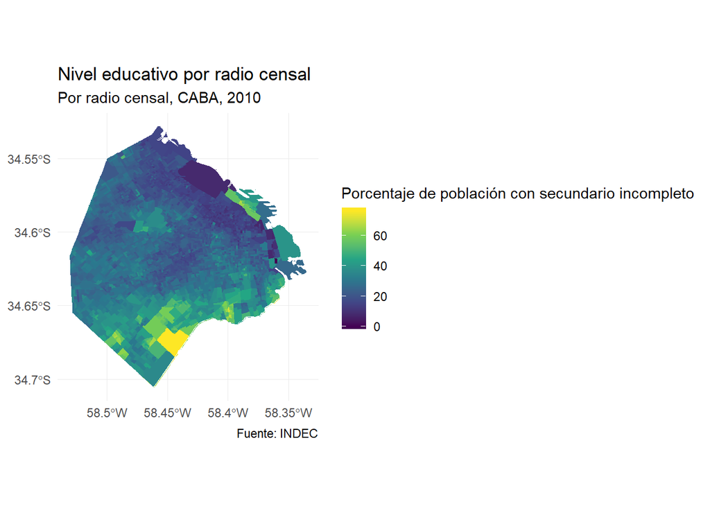

```r
ggplot() +
    geom_sf(data = censo, aes (fill= Z_NEDU10), color=NA) +
  scale_fill_viridis_c() +
  theme_minimal() +
 coord_sf(crs = st_crs(4326)) +
  labs(title = "Nivel educativo por radio censal",
         subtitle = "Por radio censal, CABA, 2010",
         caption = "Fuente: INDEC",
         fill = "Porcentaje de población con secundario incompleto")
```

Se observa que existen diferencias espaciales entre el porcentaje de población con el secundario incompleto. En el sur de la ciudad, este valor aumenta; por el contrario, se reduce a medida que nos dirigimos al noreste.